# Exploratory Mediation Analysis of the Example Datasets of the HIMA Library

##### Test for differences across groups

We are going to use the Kruskal-Wallis test to determine the difference in variance for effects, and the total log odds across sexes.

*H<sub>0</sub>* : There exists no difference in medians in any effects and the total log odds across male and female subjects.

*H<sub>1</sub>* : There exists a difference in medians in any effects and the total log odds across male and female subjects.

```r
E2classic_kruskal_sex <- perform_kruskal(E2classic, "Sex", c(hima.logistic.fit[,"Index"], "Direct", "Adjusted"))
```

```
## [1] "M1"
## [1] "M2"
## [1] "M3"
## [1] "Direct"
## [1] "Adjusted"
```

```r
E2classic_kruskal_sex
```

```
## $M1
##
##  Kruskal-Wallis rank sum test
##
## data:  y_val by x_val
## Kruskal-Wallis chi-squared = 0.084627, df = 1, p-value = 0.7711
##
##
## $M2
##
##  Kruskal-Wallis rank sum test
##
## data:  y_val by x_val
## Kruskal-Wallis chi-squared = 0.778, df = 1, p-value = 0.3778
##
##
## $M3
##
##  Kruskal-Wallis rank sum test
##
## data:  y_val by x_val
## Kruskal-Wallis chi-squared = 0.11123, df = 1, p-value = 0.7387
##
##
## $Direct
##
##  Kruskal-Wallis rank sum test
##
## data:  y_val by x_val
## Kruskal-Wallis chi-squared = 21.987, df = 1, p-value = 2.745e-06
##
##
## $Adjusted
##
##  Kruskal-Wallis rank sum test
##
## data:  y_val by x_val
## Kruskal-Wallis chi-squared = 0.91763, df = 1, p-value = 0.3381
```

The null hypothesis can be rejected. There exists a statistically significant difference in medians for the direct effect across male and female subjects.

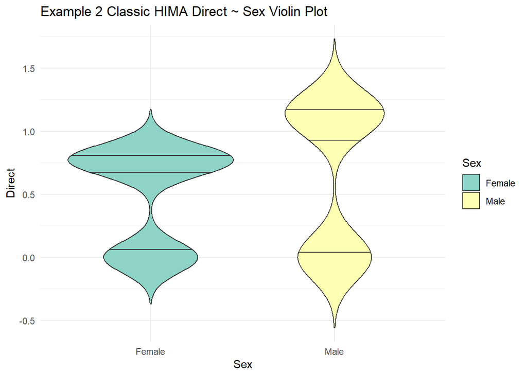

```r
E2classic$Sex <- ifelse(E2classic$Sex == 0, "Male", "Female")
E2classic_sex_pl <- plot_violins(E2classic, "Sex", "Direct", plotname = "Example 2 Classic HIMA Direct ~ Sex Violin Plot")
E2classic_sex_pl
```

```r
boot_tests(E2classic, "Sex", "Direct", mean)
```

```
##             2.5%     97.5%
## Female 0.4359854 0.5507760
## Male   0.5743027 0.7420187
```

Females have decreased sensitivity to the direct effect of the Treatment. We shall move on to testing the correlation between effects and different disease outcomes.

*H<sub>0</sub>* : There exists no difference in medians in any effects and the total log odds across disease positive and disease negative subjects.

*H<sub>1</sub>* : There exists a difference in medians in any effects and the total log odds across disease positive and disease negative subjects.

```r
E2classic_kruskal_disease <- perform_kruskal(E2classic, "Disease", c(hima.logistic.fit[,"Index"], "Direct", "Adjusted"))
```

```
## [1] "M1"
## [1] "M2"
## [1] "M3"
## [1] "Direct"
## [1] "Adjusted"
```

```r
E2classic_kruskal_disease
```

```
## $M1
##
##  Kruskal-Wallis rank sum test
##
## data:  y_val by x_val
## Kruskal-Wallis chi-squared = 34.128, df = 1, p-value = 5.16e-09
##
##
## $M2
##
##  Kruskal-Wallis rank sum test
##
## data:  y_val by x_val
## Kruskal-Wallis chi-squared = 37.055, df = 1, p-value = 1.148e-09
##
##
## $M3
##
##  Kruskal-Wallis rank sum test
##
## data:  y_val by x_val
## Kruskal-Wallis chi-squared = 10.665, df = 1, p-value = 0.001092
##
##
## $Direct
##
##  Kruskal-Wallis rank sum test
##
## data:  y_val by x_val
## Kruskal-Wallis chi-squared = 26.055, df = 1, p-value = 3.317e-07
##
##
## $Adjusted
##
##  Kruskal-Wallis rank sum test
##
## data:  y_val by x_val
## Kruskal-Wallis chi-squared = 89.389, df = 1, p-value < 2.2e-16
```

The null hypothesis can be rejected(adjusted p < 0.05). For all effects, there is a difference in medians across different disease statuses.

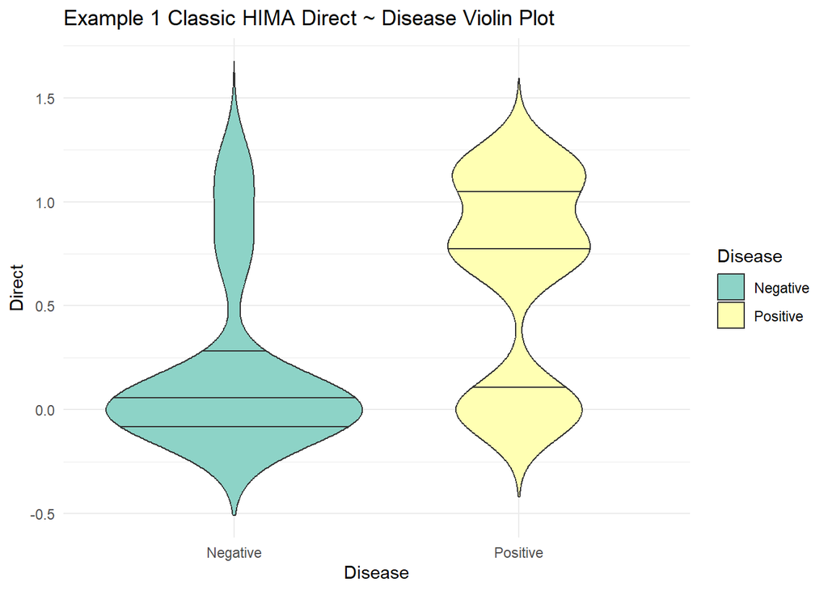

```r
E2classic$Disease <- ifelse(E2classic$Disease == 0, "Negative", "Positive")
E2classic_disease_pl <- plot_violins(E2classic, "Disease", "Direct", plotname = "Example 1 Classic HIMA Direct ~ Disease Violin Plot")
E2classic_disease_pl
```

```r
boot_tests(E2classic, "Disease", "Direct", mean)
```

```
##                2.5%     97.5%
## Positive 0.58718117 0.7030592
## Negative 0.09232616 0.3251579
```

```r
boot_tests(E2classic, "Disease", "M1", mean)
```

```
##                2.5%       97.5%
## Positive  0.9828000  1.38232436
## Negative -0.9017798 -0.02759595
```

```r
boot_tests(E2classic, "Disease", "M2", mean)
```

```
##                2.5%       97.5%
## Positive  0.9360903  1.30562846
## Negative -0.9220151 -0.07787245
```

```r
boot_tests(E2classic, "Disease", "M3", mean)
```

```
##                 2.5%        97.5%
## Positive  0.08059985  0.230785901
## Negative -0.42053939 -0.007521869
```

##### Findings

The results of **classicHIMA** for Example 2 show:

The values for each effect are not normally distributed.

All effects have a positive correlation with the log-odds ratio for P(1 | X, M, Cov).

Males are more susceptible to the direct effect than females.

For negative disease test outcomes, the mediator effects had a negative effect, while the Direct retained a smaller yet still positive effect.

### Mediation Analysis with MCP HIMA

#### Mediator Identification

```r
e2 <- himaFit(Disease ~ Treatment + Sex + Age,
              data.pheno = himaDat$Example2$PhenoData,
              data.M = himaDat$Example2$Mediator,
              mediator.type = "gaussian",
              penalty = "MCP",
              scale = FALSE
) # Disabled only for simulation data
```

```
## Running logistic HIMA with MCP penalty...
```

```
## Step 1: Sure Independent Screening ...     (3:04:19 PM)
```

```
## Step 2: Penalized estimate (MCP) ...     (3:04:20 PM)
```

```
##     Using alpha estimated in Step 1 ...   (3:04:20 PM)
```

```
## Step 3: Joint significance test ...     (3:04:20 PM)
```

```
## Done!     (3:04:20 PM)
```

```r
e2
```

```
##   ID      alpha       beta alpha*beta Relative Importance (%)      p-value
## 1 M2  0.9677835  1.0148114  0.9821177                48.21264 9.257657e-08
## 2 M3 -0.6657028 -0.4412061  0.2937121                14.41847 7.601026e-04
## 3 M1  0.6096868  1.0393063  0.6336514                31.10626 1.478678e-03
```

```r
summary(Example2$Mediator[,e2[,"ID"]])
```

```
##        M2                M3                M1
##  Min.   :-3.1423   Min.   :-4.4413   Min.   :-3.3039
##  1st Qu.:-0.0914   1st Qu.:-1.2927   1st Qu.:-0.1965
##  Median : 0.9824   Median :-0.1783   Median : 0.9708
##  Mean   : 0.8541   Mean   :-0.2224   Mean   : 0.8834
##  3rd Qu.: 1.9565   3rd Qu.: 0.6971   3rd Qu.: 1.9642
##  Max.   : 6.6554   Max.   : 4.4498   Max.   : 5.0112
```

M1, M2, and M3 have been identified as the top three most significant mediator variables. (p < 0.05)

**alpha_hat** represents the effect the treatment has on the mediators.

**beta_hat** represents the effect the mediators have towards the outcome.

**IDE** stands for “Indirect Effect”, and is the result of **alpha_hat*beta_hat**.

```r
E2mcp <- estimatedEffects(fit = e2,
                          betas = e2[,"beta"],
                          IDEcoefs = e2[,"alpha*beta"],
                          type = "binary",
                          dat = himaDat$Example2,
                          X = himaDat$Example2$PhenoData$Treatment,
                          Y = himaDat$Example2$PhenoData$Disease,
                          Cov = himaDat$Example2$PhenoData[, c("Sex", "Age")])

attributes(e2)$variable.labels
```

```
## [1] "ID: Mediator ID"
## [2] "alpha: Effect of exposure on mediator"
## [3] "beta: Effect of mediator on outcome"
## [4] "alpha*beta: Mediation (indirect) effect"
## [5] "Relative Importance (%): Relative importance of the mediator out of all significant mediators"
## [6] "p-value: Joint raw p-value of significant mediator selected based on Bonferroni-adjusted p < 0.05"
```

```r
E2mcpmodelpl <- plot_mediator_adjustments(type = "binary",
                                  actual = himaDat$Example2$PhenoData$Disease,
                                  estimations = E2mcp,
                                  mediator_indices = e2[,"ID"],
                                  plotname = "Example Two MCP HIMA Outcome Predictions",
                                  labels = c("Disease", "Negative", "Positive"))
```

```
##            actual
## predoutcome   0   1
##           0  34  22
##           1  13 231
##         mcc
## 1 0.5937218
```

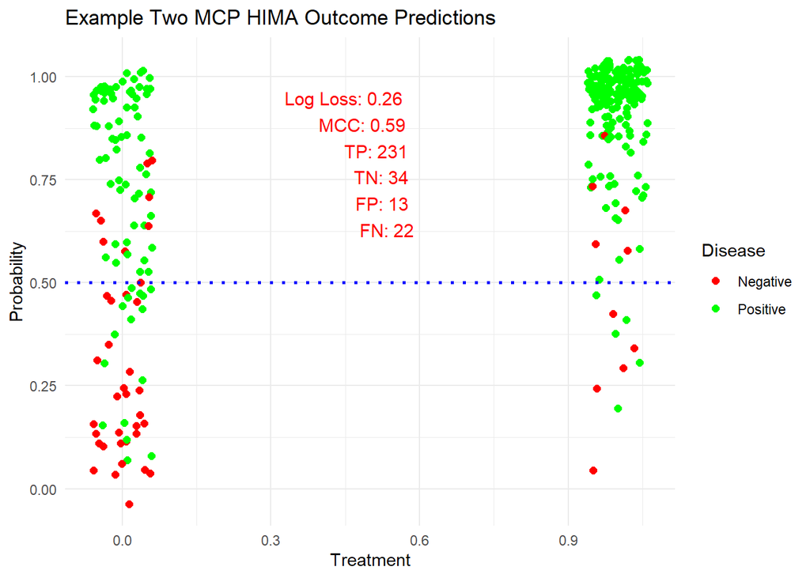

```r
E2mcpmodelpl
```

The consideration of mediators allows the relationship between Treatment and Outcome to be much more accurately described.

The contribution towards the outcome by each mediator is calculated as **M * beta_hat.**

The contribution towards the outcome by the Direct Effect is calculated as the **E(Y | X, Cov) - IDE**.

The mediator adjusted prediction is **E(Y | X, M, Cov) = 𝛽*M + E(Y | X, Cov) - IDE**.

#### Effect Analysis

##### Test for Normality

*H<sub>0</sub>* : The values for every type of measured effect are drawn from the normal distribution.

*H<sub>1</sub>* : The values for every type of measured effect are drawn from outside the normal distribution.

```r
E2mcp_control_ks_results <- kstests(dat = E2mcp[E2mcp$Treatment == 0,], exclude = c("Treatment","Sex","Other", "DominantEffect", "Direct"))
```

```
## [1] "Disease"      "Age"          "M2"           "M3"           "M1"
## [6] "totalLogOdds" "Residuals"    "Adjusted"
```

```r
print(data.frame(E2mcp_control_ks_results))
```

```
##              D_Statistic       P_Value
## Disease        0.5277854  5.632513e-29
## Age            1.0000000 6.419959e-103
## M2             0.2594766  2.513832e-07
## M3             0.1468597  1.231608e-02
## M1             0.3033112  7.445057e-10
## totalLogOdds   0.7105682  3.559016e-52
## Residuals      0.1942909  2.704010e-04
## Adjusted       0.3176870  9.054633e-11
```

```r
E2mcp_experimental_ks_results <- kstests(dat = E2mcp[E2mcp$Treatment != 0,], exclude = c("Treatment","Sex","Other", "DominantEffect", "Direct"))
```

```
## [1] "Disease"      "Age"          "M2"           "M3"           "M1"
## [6] "totalLogOdds" "Residuals"    "Adjusted"
```

```r
print(data.frame(E2mcp_experimental_ks_results))
```

```
##              D_Statistic       P_Value
## Disease        0.7863997  3.455536e-98
## Age            1.0000000 1.651348e-158
## M2             0.4174129  5.723249e-28
## M3             0.1989352  1.108799e-06
## M1             0.3891530  2.295653e-24
## totalLogOdds   0.9959908 3.040010e-157
## Residuals      0.6174098  1.097805e-60
## Adjusted       0.7460679  2.037984e-88
```

##### Tests for Correlation

We reject *H<sub>0</sub>* (p < 0.05). In rejection of the null hypothesis, we shall test for whether there exists correlations between each mediator effect.

*H<sub>0</sub>* : There exists no correlation between a mediator effect and any other mediator effect.

*H<sub>1</sub>* : There exists a correlation between an effect and any other mediator effect.

```r
E2mcp_effect_cor <- perform_cor_tests(E2mcp, c(e2[,"ID"]), alternative = "two.sided", method = "spearman")
E2mcp_effect_cor
```

```
## $`M2 - M3`
##
##  Spearman's rank correlation rho
##
## data:  data[, x[i]] and data[, x[j]]
## S = 3959092, p-value = 0.03752
## alternative hypothesis: true rho is not equal to 0
## sample estimates:
##      rho
## 0.120192
##
##
## $`M2 - M1`
##
##  Spearman's rank correlation rho
##
## data:  data[, x[i]] and data[, x[j]]
## S = 4383122, p-value = 0.6541
## alternative hypothesis: true rho is not equal to 0
## sample estimates:
##        rho
## 0.02596207
##
##
## $`M3 - M1`
##
##  Spearman's rank correlation rho
##
## data:  data[, x[i]] and data[, x[j]]
## S = 4808868, p-value = 0.2357
## alternative hypothesis: true rho is not equal to 0
## sample estimates:
##         rho
## -0.06864921
```

*H<sub>0</sub>* : There exists no correlation between an effect and any other effect in the experimental group.

*H<sub>1</sub>* : There exists a correlation between an effect and any other effect in the experimental group.

```r
E2mcp_effect_cor_e <- perform_cor_tests(E2mcp[E2mcp$Treatment > 0,], c(e2[,"ID"], "Direct"), alternative = "two.sided", method = "spearman")
E2mcp_effect_cor_e
```

```
## $`M2 - M3`
##
##  Spearman's rank correlation rho
##
## data:  data[, x[i]] and data[, x[j]]
## S = 905246, p-value = 0.1834
## alternative hypothesis: true rho is not equal to 0
## sample estimates:
##        rho
## 0.09901655
##
##
## $`M2 - M1`
##
##  Spearman's rank correlation rho
##
## data:  data[, x[i]] and data[, x[j]]
## S = 923096, p-value = 0.2753
## alternative hypothesis: true rho is not equal to 0
## sample estimates:
##       rho
## 0.0812506
##
##
## $`M2 - Direct`
##
##  Spearman's rank correlation rho
##
## data:  data[, x[i]] and data[, x[j]]
## S = 870038, p-value = 0.07119
## alternative hypothesis: true rho is not equal to 0
## sample estimates:
##      rho
## 0.134059
##
##
## $`M3 - M1`
##
##  Spearman's rank correlation rho
##
```

[output cut: 15 more lines]

```
## sample estimates:
##         rho
## -0.06957232
##
##
## $`M1 - Direct`
##
##  Spearman's rank correlation rho
##
## data:  data[, x[i]] and data[, x[j]]
## S = 914378, p-value = 0.2273
## alternative hypothesis: true rho is not equal to 0
## sample estimates:
##        rho
## 0.08992778
```

We fail to reject the null hypothesis: The correlation between each effect is not statistically significant( p > 0.05). We will conduct bootstrap sampling to find the true mean of each effect in the control group and experimental group.

```r
E2mcp_control_long <- melt(E2mcp[E2mcp$Treatment == 0,e2[,"ID"]], variable.name = "Effect", value.name = "Contribution")
head(E2mcp_control_long)
```

```
##   Effect Contribution
## 1     M2    1.5490687
## 2     M2    1.0396672
## 3     M2    0.7376995
## 4     M2    1.9687586
## 5     M2    6.7539519
## 6     M2   -1.3075329
```

```r
E2mcp_control_pl <- plot_violins(E2mcp_control_long, x = "Effect", y = "Contribution", "Example 2 MCP HIMA Control Group Effects")
E2mcp_control_boot <- boot_tests(data = E2mcp_control_long, x = "Effect", y = "Contribution", statistic = mean)
E2mcp_control_boot
```

```
##            2.5%     97.5%
## M2  0.003518651 0.5926406
## M3 -0.198147600 0.0331577
## M1  0.211920809 0.8634395
```

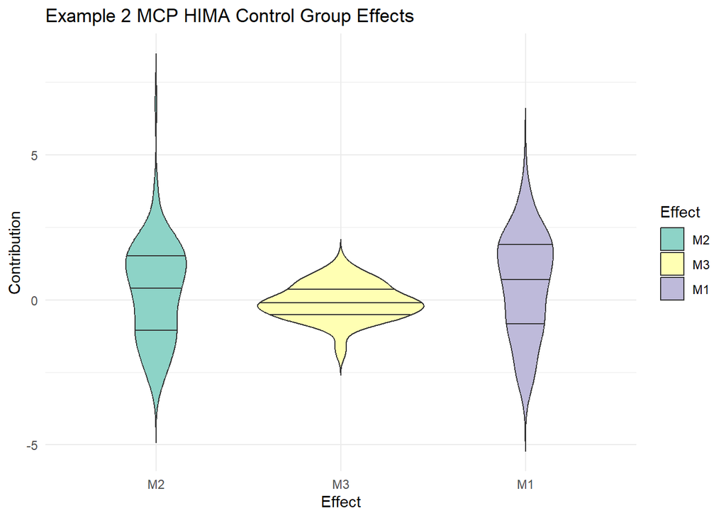

```r
E2mcp_control_pl
```

```r
E2mcp_experimental_long <- melt(E2mcp[E2mcp$Treatment != 0,c(e2[,"ID"], "Direct")], variable.name = "Effect", value.name = "Contribution")
head(E2mcp_experimental_long)
```

```
##   Effect Contribution
## 1     M2  -0.04710260
## 2     M2   1.70201533
## 3     M2   2.95262911
## 4     M2   0.04205882
## 5     M2   2.54494157
## 6     M2   2.10971636
```

```r
E2mcp_experimental_pl <- plot_violins(E2mcp_experimental_long, x = "Effect", y = "Contribution", "Example 2 MCP HIMA Experimental Group Effects")
E2mcp_experimental_boot <- boot_tests(data = E2mcp_experimental_long, x = "Effect", y = "Contribution", statistic = mean)
E2mcp_experimental_boot
```

```
##             2.5%     97.5%
## M2     1.0329037 1.4442555
## M3     0.1253084 0.3103900
## M1     0.9286745 1.4048884
## Direct 0.9238782 0.9772399
```

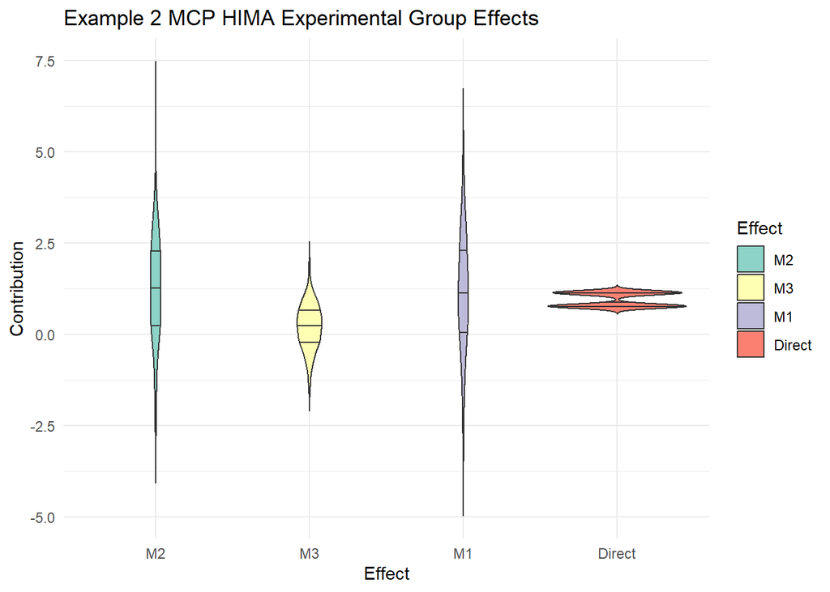

```r
E2mcp_experimental_pl
```

In the experimental group, the mean contributions of each effect are much higher than they are in the control group.

We are going to test for correlations between effects and the adjusted log-odds ratio for P(1 | X, M, Cov).

*H<sub>0</sub>* : There exists no correlation between any effect and measured outcome in the experimental group.

*H<sub>1</sub>* : There exists a correlation between any effect and measured outcome in the experimental group.

```r
E2mcp_effect_lor_cor <- perform_cor_tests(E2mcp, x = c(e2[,"ID"], "Direct"), y = "Adjusted", alternative = "two.sided", method = "spearman")
E2mcp_effect_lor_cor
```

```
## $`M2 - Adjusted`
##
##  Spearman's rank correlation rho
##
## data:  data[, name] and data[, y]
## S = 1516972, p-value < 2.2e-16
## alternative hypothesis: true rho is not equal to 0
## sample estimates:
##       rho
## 0.6628914
##
##
## $`M3 - Adjusted`
##
##  Spearman's rank correlation rho
##
## data:  data[, name] and data[, y]
## S = 3229260, p-value = 7.393e-07
## alternative hypothesis: true rho is not equal to 0
## sample estimates:
##       rho
## 0.2823787
##
##
## $`M1 - Adjusted`
##
##  Spearman's rank correlation rho
##
## data:  data[, name] and data[, y]
## S = 1589100, p-value < 2.2e-16
## alternative hypothesis: true rho is not equal to 0
## sample estimates:
##       rho
## 0.6468627
##
##
## $`Direct - Adjusted`
##
##  Spearman's rank correlation rho
##
## data:  data[, name] and data[, y]
## S = 2166848, p-value < 2.2e-16
## alternative hypothesis: true rho is not equal to 0
## sample estimates:
##       rho
## 0.5184728
```

We can reject the null hypothesis(adjusted p < 0.05). For all effects, there exists positive correlation to the log-odds ratio for P(1 | X, M, Cov). We shall move on to testing for correlation between age and all effects.

*H<sub>0</sub>* : There exists no correlation between any effect and age in the experimental group.

*H<sub>1</sub>* : There exists a correlation between any effect and age in the experimental group.

```r
E2mcp_effect_age_cor <- perform_cor_tests(E2mcp, x = c(e2[,"ID"], "Direct"), y = "Age", alternative = "two.sided", method = "spearman")
E2mcp_effect_age_cor
```

```
## $`M2 - Age`
##
##  Spearman's rank correlation rho
##
## data:  data[, name] and data[, y]
## S = 3887503, p-value = 0.01835
## alternative hypothesis: true rho is not equal to 0
## sample estimates:
##       rho
## 0.1361008
##
##
## $`M3 - Age`
##
##  Spearman's rank correlation rho
##
## data:  data[, name] and data[, y]
## S = 4731162, p-value = 0.3752
## alternative hypothesis: true rho is not equal to 0
## sample estimates:
##         rho
## -0.05138092
##
##
## $`M1 - Age`
##
##  Spearman's rank correlation rho
##
## data:  data[, name] and data[, y]
## S = 4054046, p-value = 0.08665
## alternative hypothesis: true rho is not equal to 0
## sample estimates:
##        rho
## 0.09909094
##
##
## $`Direct - Age`
##
##  Spearman's rank correlation rho
##
## data:  data[, name] and data[, y]
## S = 3948223, p-value = 0.03377
## alternative hypothesis: true rho is not equal to 0
## sample estimates:
##       rho
## 0.1226073
```

We fail to reject the null hypothesis(adjusted p < 0.05). There is little statistical significance in the correlation between effects and age.

##### Test for differences across groups

We are going to use the Kruskal-Wallis test to determine the difference in variance for effects, and the total log odds across sexes.

*H<sub>0</sub>* : There exists no difference in medians in any effects and the total log odds across male and female subjects.

*H<sub>1</sub>* : There exists a difference in medians in any effects and the total log odds across male and female subjects.

```r
E2mcp_kruskal_sex <- perform_kruskal(E2mcp, "Sex", c(e2[,"ID"], "Direct", "Adjusted"))
```

```
## [1] "M2"
## [1] "M3"
## [1] "M1"
## [1] "Direct"
## [1] "Adjusted"
```

```r
E2mcp_kruskal_sex
```

```
## $M2
##
##  Kruskal-Wallis rank sum test
##
## data:  y_val by x_val
## Kruskal-Wallis chi-squared = 0.778, df = 1, p-value = 0.3778
##
##
## $M3
##
##  Kruskal-Wallis rank sum test
##
## data:  y_val by x_val
## Kruskal-Wallis chi-squared = 0.11123, df = 1, p-value = 0.7387
##
##
## $M1
##
##  Kruskal-Wallis rank sum test
##
## data:  y_val by x_val
## Kruskal-Wallis chi-squared = 0.084627, df = 1, p-value = 0.7711
##
##
## $Direct
##
##  Kruskal-Wallis rank sum test
##
## data:  y_val by x_val
## Kruskal-Wallis chi-squared = 21.987, df = 1, p-value = 2.745e-06
##
##
## $Adjusted
##
##  Kruskal-Wallis rank sum test
##
## data:  y_val by x_val
## Kruskal-Wallis chi-squared = 0.91763, df = 1, p-value = 0.3381
```

The null hypothesis can be rejected. There exists a statistically significant difference in medians for the direct effect across male and female subjects.

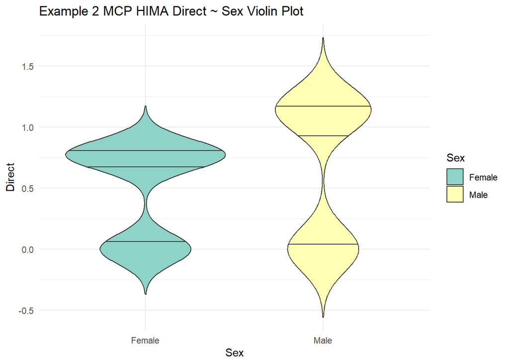

```r
E2mcp$Sex <- ifelse(E2mcp$Sex == 0, "Male", "Female")
E2mcp_sex_pl <- plot_violins(E2mcp, "Sex", "Direct", plotname = "Example 2 MCP HIMA Direct ~ Sex Violin Plot")
E2mcp_sex_pl
```

```r
boot_tests(E2mcp, "Sex", "Direct", mean)
```

```
##             2.5%     97.5%
## Female 0.4358723 0.5533844
## Male   0.5673302 0.7398330
```

Females have decreased sensitivity to the direct effect of the Treatment. We shall move on to testing the correlation between effects and different disease outcomes.

*H<sub>0</sub>* : There exists no difference in medians in any effects and the total log odds across disease positive and disease negative subjects.

*H<sub>1</sub>* : There exists a difference in medians in any effects and the total log odds across disease positive and disease negative subjects.

```r
E2mcp_kruskal_disease <- perform_kruskal(E2mcp, "Disease", c(e2[,"ID"], "Direct", "Adjusted"))
```

```
## [1] "M2"
## [1] "M3"
## [1] "M1"
## [1] "Direct"
## [1] "Adjusted"
```

```r
E2mcp_kruskal_disease
```

```
## $M2
##
##  Kruskal-Wallis rank sum test
##
## data:  y_val by x_val
## Kruskal-Wallis chi-squared = 37.055, df = 1, p-value = 1.148e-09
##
##
## $M3
##
##  Kruskal-Wallis rank sum test
##
## data:  y_val by x_val
## Kruskal-Wallis chi-squared = 10.665, df = 1, p-value = 0.001092
##
##
## $M1
##
##  Kruskal-Wallis rank sum test
##
## data:  y_val by x_val
## Kruskal-Wallis chi-squared = 34.128, df = 1, p-value = 5.16e-09
##
##
## $Direct
##
##  Kruskal-Wallis rank sum test
##
## data:  y_val by x_val
## Kruskal-Wallis chi-squared = 26.055, df = 1, p-value = 3.317e-07
##
##
## $Adjusted
##
##  Kruskal-Wallis rank sum test
##
## data:  y_val by x_val
## Kruskal-Wallis chi-squared = 89.389, df = 1, p-value < 2.2e-16
```

The null hypothesis can be rejected(adjusted p < 0.05). For all effects, there is a difference in medians across different disease statuses.

[figure not shown]

```r
E2mcp$Disease <- ifelse(E2mcp$Disease == 0, "Negative", "Positive")
E2mcp_disease_pl <- plot_violins(E2mcp, "Disease", "Direct", plotname = "Example 2 MCP HIMA Direct ~ Disease Violin Plot")
E2classic_disease_pl
```

```r
boot_tests(E2mcp, "Disease", "Direct", mean)
```

```
##                2.5%     97.5%
## Positive 0.58800432 0.7058901
## Negative 0.09853407 0.3259679
```

```r
boot_tests(E2mcp, "Disease", "M1", mean)
```

```
##                2.5%        97.5%
## Positive  0.9853373  1.374312441
## Negative -0.8936239 -0.008503086
```

```r
boot_tests(E2mcp, "Disease", "M2", mean)
```

```
##                2.5%       97.5%
## Positive  0.9437393  1.29293481
## Negative -0.9613777 -0.07470126
```

```r
boot_tests(E2mcp, "Disease", "M3", mean)
```

```
##                 2.5%      97.5%
## Positive  0.08267895  0.2298223
## Negative -0.40367469 -0.0154387
```

##### Findings

The results of **MCP HIMA** for Example 2 show:

The values for each effect are not normally distributed.

There exists positive correlation between M2 and M3.

All effects have a positive correlation with the log-odds ratio for P(1 | X, M, Cov).

Males are more sensitive to the direct effect than females.

For negative disease test outcomes, the mediator effects had a negative effect, while the Direct retained a smaller yet still positive effect.

#### Conclusion

When run on the data of Example 2, both **classic HIMA** and **MCP HIMA** yield the same statisticallly significant findings and similar calculations for contributions of each effect. Though a vast improvement from the original, the model requires further refinement.

## Example 3 Data Overview

### Dimensions of the Data

```r
dim(Example3$PhenoData)
```

```
## [1] 200   5
```

```r
dim(Example3$Mediator)
```

```
## [1] 200 200
```

### Data Overview

Numerical Features

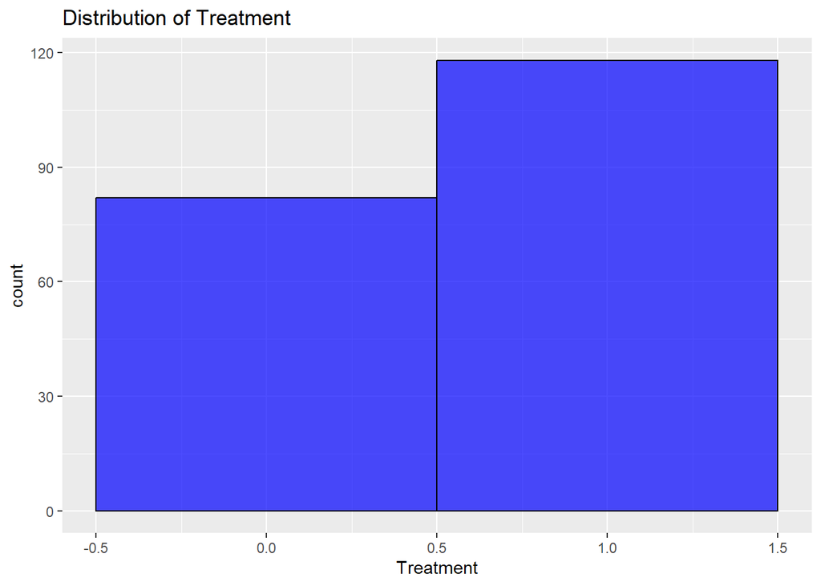

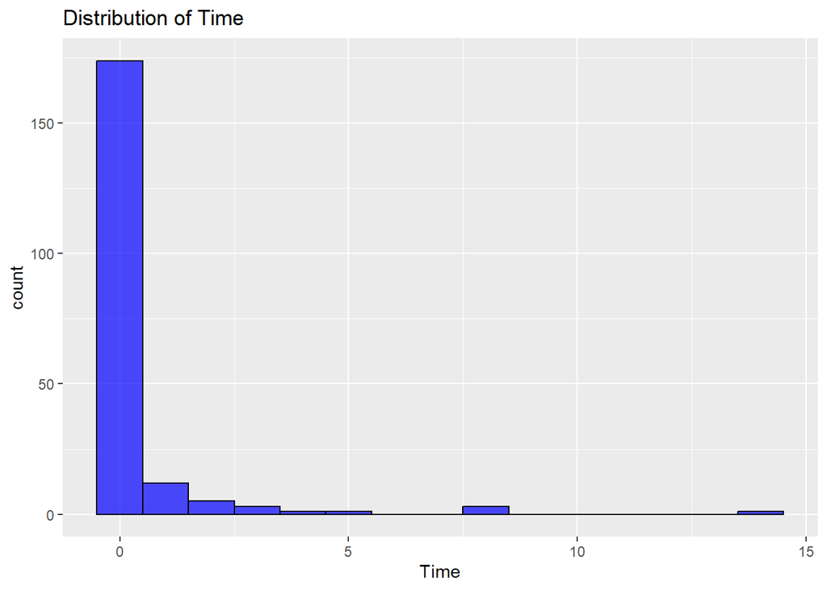

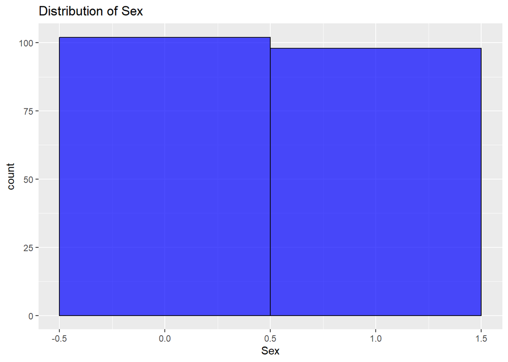

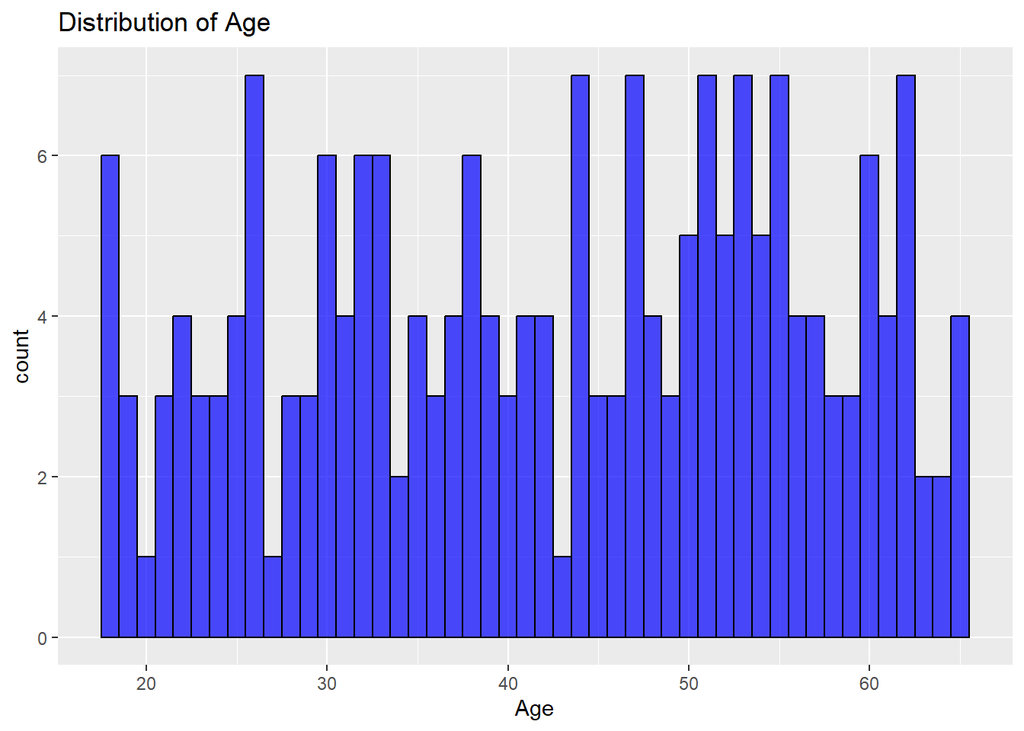

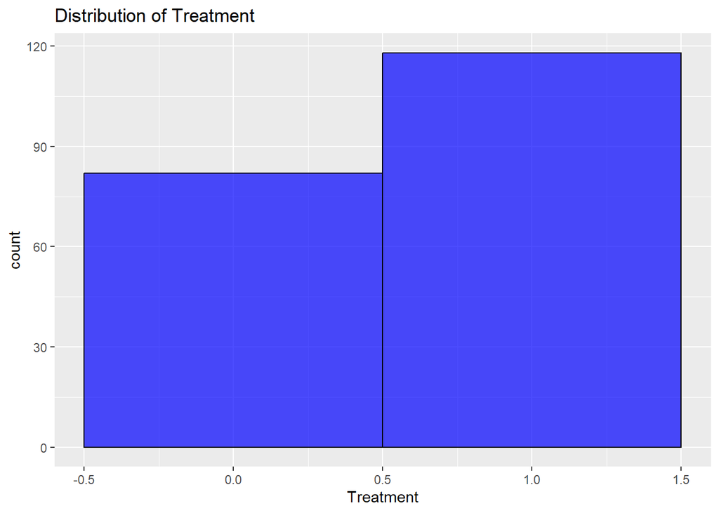

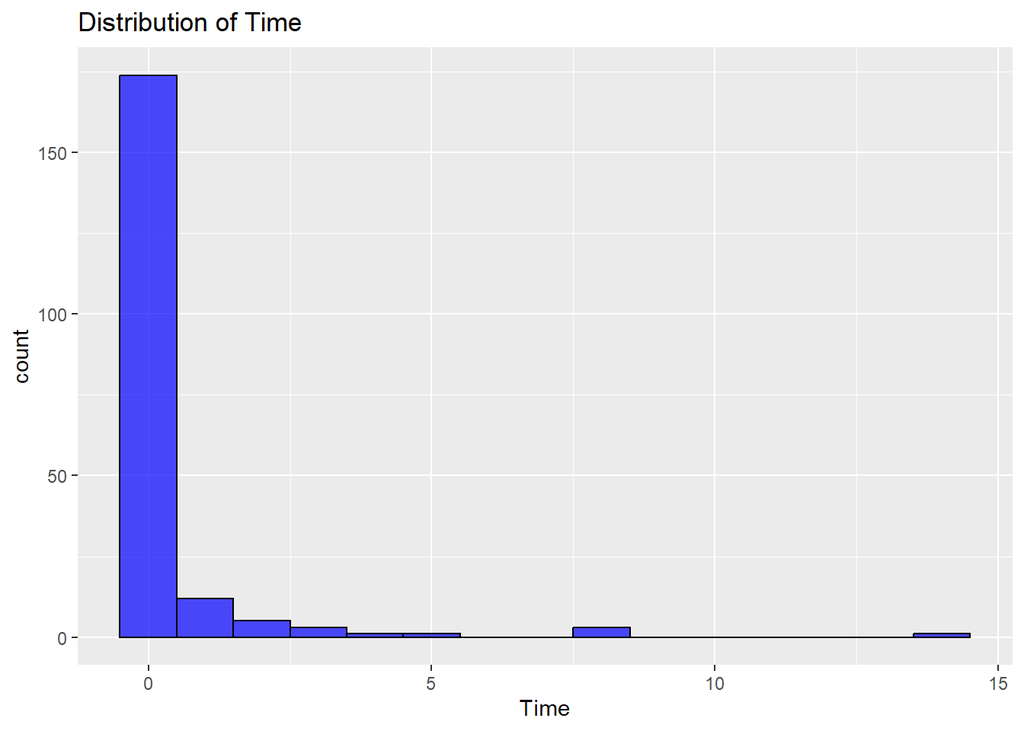

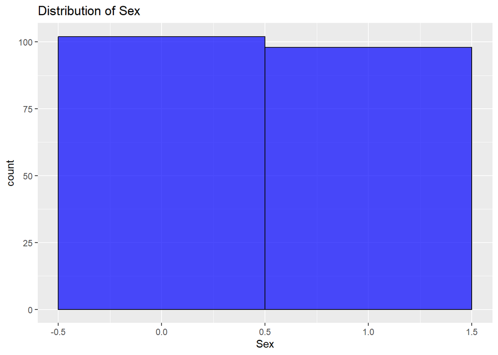

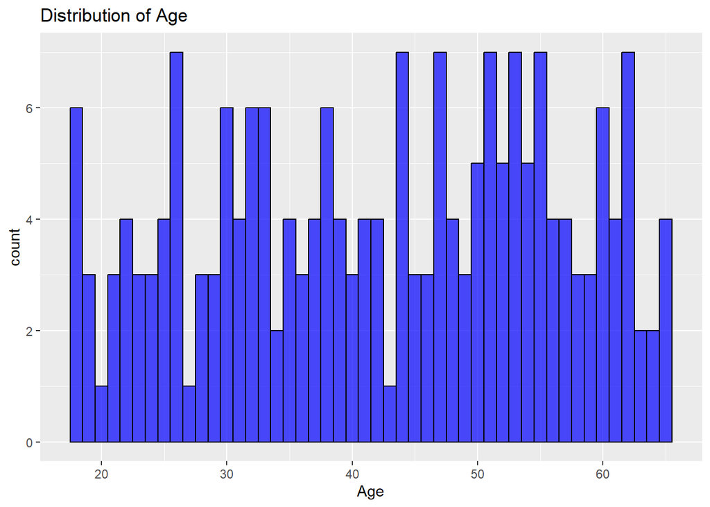

```r
# Histograms for numerical features
num_vars <- sapply(Example3$PhenoData, is.numeric)
data_numeric <- Example3$PhenoData[, num_vars]
lapply(names(data_numeric), function(var) {
  print(ggplot(Example3$PhenoData, aes_string(x = var)) +
        geom_histogram(binwidth = 1, fill = "blue", color = "black", alpha = 0.7) +
        labs(title = paste("Distribution of", var)))
})
```

```r
summary(Example3$PhenoData)
```

```
##    Treatment      Status             Time               Sex
##  Min.   :0.00   Mode :logical   Min.   : 0.00013   Min.   :0.00
##  1st Qu.:0.00   FALSE:1         1st Qu.: 0.01189   1st Qu.:0.00
##  Median :1.00   TRUE :199       Median : 0.04675   Median :0.00
##  Mean   :0.59                   Mean   : 0.46126   Mean   :0.49
##  3rd Qu.:1.00                   3rd Qu.: 0.22169   3rd Qu.:1.00
##  Max.   :1.00                   Max.   :14.35896   Max.   :1.00
##       Age
##  Min.   :18.00
##  1st Qu.:31.00
##  Median :44.00
##  Mean   :42.45
##  3rd Qu.:54.00
##  Max.   :65.00
```

**Treatment**: A binary feature that indicates the presence of the treatment for a test subject. **1** indicates the presence of the treatment. **0** indicates the absence of the treatment.

**Time**: A continuous feature that indicates the survival time of a subject. Units are ambiguous.

**Status**: A censorship indicator for the status of the subject.

**Sex**: A binary feature that indicates the biological sex of the subject. **1** indicates females, and **0** indicates males.

**Age**: A continuous numerical features that represents the age of the subject in years.

Categorical Features

```r
# Bar plots for categorical features
cat_vars <- sapply(Example2$PhenoData, is.factor)
data_categorical <- Example2$PhenoData[, cat_vars, drop = FALSE]
lapply(names(data_categorical), function(var) {
  print(ggplot(Example2$PhenoData, aes_string(x = var)) +
        geom_bar(fill = "blue", color = "black", alpha = 0.7) +
        labs(title = paste("Frequency of", var)))
})
```

```
## list()
```

### Example 3 Prediction Model

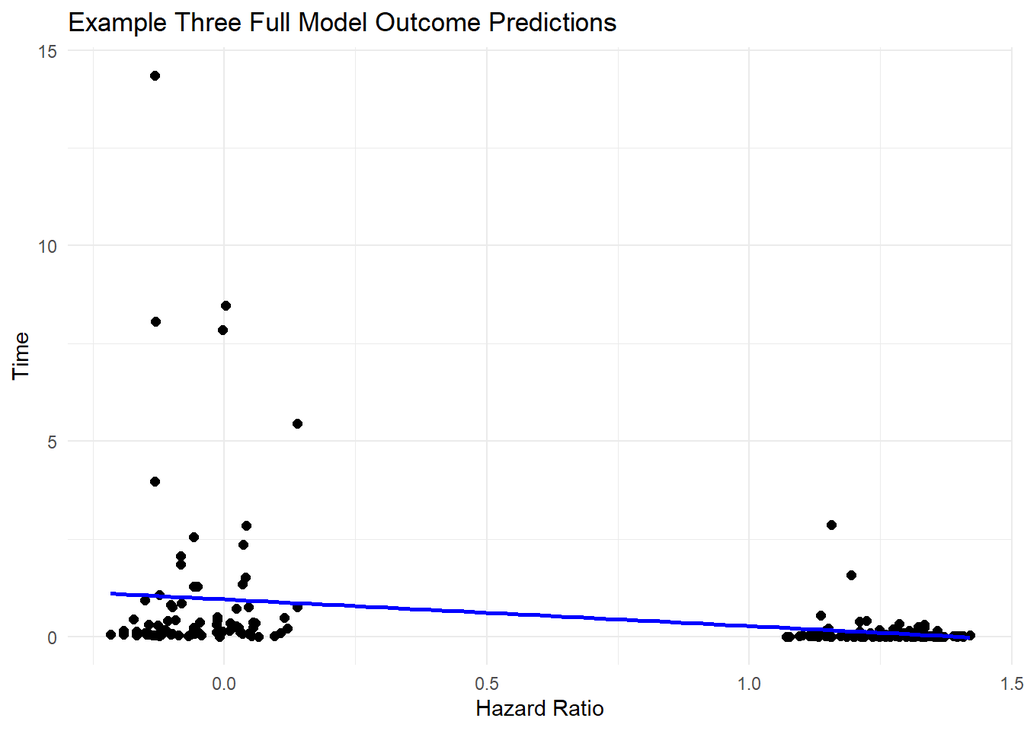

```r
Example3model <- coxph(Surv(Time, Status) ~ Treatment + Sex + Age, data = himaDat$Example3$PhenoData)
Example3modelpl <- ggplot(data.frame(Predicted = predict(Example3model),
                                         himaDat$Example3$PhenoData),
                              aes(x = Predicted, y = Time)) +
  geom_point(color = "black", size = 2) +
  geom_smooth(method = "lm", se = FALSE, color = "blue") +
  labs(title = "Example Three Full Model Outcome Predictions", x = "Hazard Ratio", y = "Time", color = "Disease\n") +
  theme_minimal()
Example3modelpl
```

### Mediation Analysis with survHIMA

#### Mediator Identification

```r
survHIMA.fit <- survHIMA(
  X = himaDat$Example3$PhenoData$Treatment,
  M = himaDat$Example3$Mediator,
  OT = himaDat$Example3$PhenoData$Time,
  status = himaDat$Example3$PhenoData$Status,
  COV = himaDat$Example3$PhenoData[, c("Sex", "Age")],
  scale = FALSE, # Disabled only for simulation data
  FDRcut = 0.05,
  verbose = TRUE
)
```

```
## Step 1: Sure Independent Screening ...     (3:04:23 PM)
```

```
##         Top 38 mediators are selected: M1, M2, M3, M7, M13, M16, M24, M25, M43, M49, M55, M63, M72, M88, M93, M95, M97, M101, M112, M113, M123, M130, M140, M141, M145, M151, M152, M162, M163, M170, M171, M173, M176, M180, M181, M183, M192, M196
```

```
## Step 2: De-biased Lasso estimates ...     (3:04:23 PM)
```

```
##         Adjusting for covariate(s): Sex, Age
```

```
## Step 3: Multiple-testing procedure ...     (3:04:53 PM)
```

```
##         3 significant mediator(s) identified.
```

```
## Done!     (3:04:53 PM)
```

```r
survHIMA.fit
```

```
##   Index  alpha_hat  alpha_se   beta_hat    beta_se       IDE     rimp
## 1    M1  1.0384367 0.1365431  0.7940717 0.08687706 0.8245932 36.74651
## 2    M2  0.6414393 0.1507081  0.8027894 0.07754965 0.5149406 22.94740
## 3    M3 -0.9087889 0.1463872 -0.9952480 0.08084286 0.9044704 40.30609
##           pmax
## 1 2.842171e-14
## 2 2.079579e-05
## 3 5.362315e-10
```

```r
summary(Example3$Mediator[,survHIMA.fit[,"Index"]])
```

```
##        M1                M2                M3
##  Min.   :-1.5690   Min.   :-1.7939   Min.   :-2.84638
##  1st Qu.: 0.2930   1st Qu.: 0.3539   1st Qu.:-0.55803
##  Median : 0.8624   Median : 0.9875   Median : 0.01806
##  Mean   : 0.9534   Mean   : 0.9513   Mean   : 0.03128
##  3rd Qu.: 1.6157   3rd Qu.: 1.6663   3rd Qu.: 0.73763
##  Max.   : 3.7504   Max.   : 4.1766   Max.   : 2.80907
```

M1, M2, and M3 have been identified as the top three most significant mediator variables. (p < 0.05)

**alpha_hat** represents the effect the treatment has on the mediators.

**beta_hat** represents the effect the mediators have towards the outcome.

**alpha_se** is the standard error for **E(M | X, Cov).**

**beta_se** is the standard error for **E(Y | M, Cov).**

**IDE** stands for “Indirect Effect”, and is the result of **alpha_hat*beta_hat**.

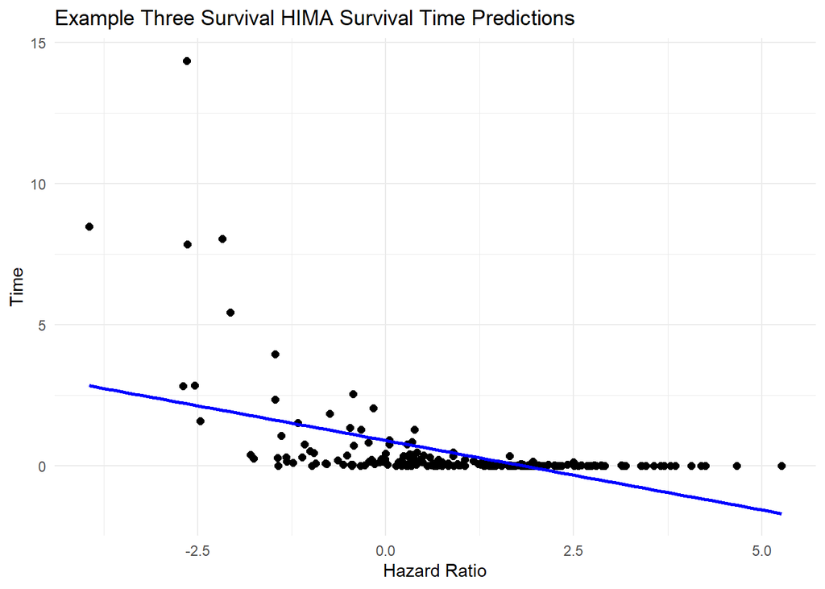

```r
E3survhima <- estimatedEffects(fit = survHIMA.fit,
                              betas = survHIMA.fit[,"beta_hat"],
                              type = "continuous",
                              dat = himaDat$Example3,
                              X = himaDat$Example3$PhenoData$Treatment,
                              Y = Surv(himaDat$Example3$PhenoData$Time, himaDat$Example3$PhenoData$Status),
                              Cov = himaDat$Example3$PhenoData[, c("Sex", "Age")])
E3survivalmodelpl <- plot_mediator_adjustments(actual = Surv(himaDat$Example3$PhenoData$Time, himaDat$Example3$PhenoData$Status),
                                  estimations = E3survhima,
                                  mediator_indices = survHIMA.fit[,"Index"],
                                  plotname = "Example Three Survival HIMA Survival Time Predictions")
E3survivalmodelpl
```

The consideration of mediators allows the relationship between Treatment and Time to be much more accurately described.

The contribution towards the outcome by each mediator is calculated as **M * beta_hat.**

The contribution towards the outcome by the Direct Effect is calculated as the **E(Y | X, Cov) - IDE**.

The mediator adjusted prediction is **E(Y | X, M, Cov) = 𝛽*M + E(Y | X, Cov) - IDE**.

#### Effect Analysis

##### Test for Normality

*H<sub>0</sub>* : The values for every type of measured effect are drawn from the normal distribution.

*H<sub>1</sub>* : The values for every type of measured effect are drawn from outside the normal distribution.

```r
E3survhima_control_ks_results <- kstests(dat = E3survhima[E3survhima$Treatment == 0,], exclude = c("Status","Treatment","Sex","Other", "DominantEffect", "Direct"))
```

```
## [1] "Time"             "Age"              "M1"               "M2"
## [5] "M3"               "totalHazardRatio" "Residuals"        "Adjusted"
```

```r
print(data.frame(E3survhima_control_ks_results))
```

```
##                  D_Statistic      P_Value
## Time               0.5005188 0.000000e+00
## Age                1.0000000 1.193260e-71
## M1                 0.1799528 8.540576e-03
## M2                 0.2920129 1.090361e-06
## M3                 0.2527968 4.174886e-05
## totalHazardRatio   0.4448050 1.618816e-14
## Residuals          0.1452926 5.651762e-02
## Adjusted           0.1470689 5.181069e-02
```

```r
E3survhima_experimental_ks_results <- kstests(dat = E3survhima[E3survhima$Treatment != 0,], exclude = c("Treatment","Sex","Other", "DominantEffect", "Direct","Status"))
```

```
## [1] "Time"             "Age"              "M1"               "M2"
## [5] "M3"               "totalHazardRatio" "Residuals"        "Adjusted"
```

```r
print(data.frame(E3survhima_experimental_ks_results))
```

```
##                  D_Statistic       P_Value
## Time               0.5000518  4.702723e-26
## Age                1.0000000 6.419959e-103
## M1                 0.5063373  1.056844e-26
## M2                 0.4683423  6.601543e-23
## M3                 0.1585245  5.313320e-03
## totalHazardRatio   0.8579203  7.295064e-76
## Residuals          0.1228534  5.676617e-02
## Adjusted           0.4814502  3.496407e-24
```

##### Tests for Correlation

*H<sub>0</sub>* : There exists no correlation between a mediator effect and any other mediator effect.

*H<sub>1</sub>* : There exists a correlation between an effect and any other mediator effect.

```r
E3survhima_effect_cor <- perform_cor_tests(E3survhima, c(survHIMA.fit[,"Index"]), alternative = "two.sided", method = "spearman")
E3survhima_effect_cor
```

```
## $`M1 - M2`
##
##  Spearman's rank correlation rho
##
## data:  data[, x[i]] and data[, x[j]]
## S = 879502, p-value = 9.57e-07
## alternative hypothesis: true rho is not equal to 0
## sample estimates:
##      rho
## 0.340357
##
##
## $`M1 - M3`
##
##  Spearman's rank correlation rho
##
## data:  data[, x[i]] and data[, x[j]]
## S = 1061706, p-value = 0.003873
## alternative hypothesis: true rho is not equal to 0
## sample estimates:
##       rho
## 0.2037006
##
##
## $`M2 - M3`
##
##  Spearman's rank correlation rho
##
## data:  data[, x[i]] and data[, x[j]]
## S = 1484190, p-value = 0.1105
## alternative hypothesis: true rho is not equal to 0
## sample estimates:
##        rho
## -0.1131703
```

We reject the null hypothesis(adjusted p < 0.05). There exists positive correlation with M1 to M2 and M1 to M3. We will follow up on this by testing for the correlation between each effect for the experimental group, where the direct effect is always present.

*H<sub>0</sub>* : There exists no correlation between an effect and any other effect in the experimental group.

*H<sub>1</sub>* : There exists a correlation between an effect and any other effect in the experimental group.

```r
E3survhima_effect_cor_e <- perform_cor_tests(E3survhima[E3survhima$Treatment > 0,], c(survHIMA.fit[,"Index"], "Direct"), alternative = "two.sided", method = "spearman")
E3survhima_effect_cor_e
```

```
## $`M1 - M2`
##
##  Spearman's rank correlation rho
##
## data:  data[, x[i]] and data[, x[j]]
## S = 213104, p-value = 0.01598
## alternative hypothesis: true rho is not equal to 0
## sample estimates:
##       rho
## 0.2217341
##
##
## $`M1 - M3`
##
##  Spearman's rank correlation rho
##
## data:  data[, x[i]] and data[, x[j]]
## S = 277480, p-value = 0.8856
## alternative hypothesis: true rho is not equal to 0
## sample estimates:
##         rho
## -0.01337015
##
##
## $`M1 - Direct`
##
##  Spearman's rank correlation rho
##
## data:  data[, x[i]] and data[, x[j]]
## S = 244139, p-value = 0.2427
## alternative hypothesis: true rho is not equal to 0
## sample estimates:
##       rho
## 0.1083945
##
##
## $`M2 - M3`
##
##  Spearman's rank correlation rho
##
```

[output cut: 15 more lines]

```
## sample estimates:
##       rho
## 0.1167373
##
##
## $`M3 - Direct`
##
##  Spearman's rank correlation rho
##
## data:  data[, x[i]] and data[, x[j]]
## S = 280224, p-value = 0.8015
## alternative hypothesis: true rho is not equal to 0
## sample estimates:
##         rho
## -0.02339203
```

```r
E3survhima_control_long <- melt(E3survhima[E3survhima$Treatment == 0,survHIMA.fit[,"Index"]], variable.name = "Effect", value.name = "Contribution")
head(E3survhima_control_long)
```

```
##   Effect Contribution
## 1     M1    1.7226757
## 2     M1    1.2602301
## 3     M1   -0.5998393
## 4     M1   -0.6492337
## 5     M1    1.0971159
## 6     M1   -1.1866920
```

```r
E3survhima_control_pl <- plot_violins(E3survhima_control_long, x = "Effect", y = "Contribution", "Example 3 survHIMA Control Group Effects")
E3survhima_control_boot <- boot_tests(data = E3survhima_control_long, x = "Effect", y = "Contribution", statistic = mean)
E3survhima_control_boot
```

```
##           2.5%      97.5%
## M1  0.09127282  0.4159661
## M2  0.25914301  0.6122774
## M3 -0.75150582 -0.3292707
```

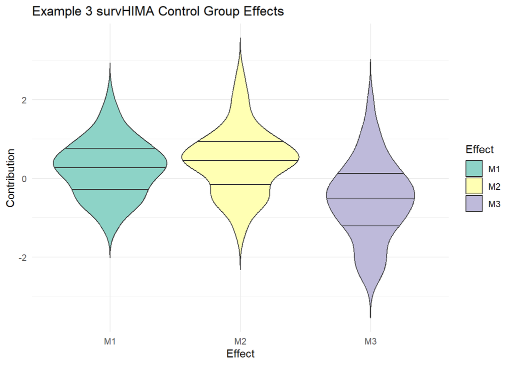

```r
E3survhima_control_pl
```

```r
E3survhima_experimental_long <- melt(E3survhima[E3survhima$Treatment != 0,c(survHIMA.fit[,"Index"], "Direct")], variable.name = "Effect", value.name = "Contribution")
head(E3survhima_experimental_long)
```

```
##   Effect Contribution
## 1     M1   0.01285601
## 2     M1  -0.60222572
## 3     M1   1.76532275
## 4     M1   0.18488892
## 5     M1   1.94504046
## 6     M1   1.39964563
```

```r
E3survhima_experimental_pl <- plot_violins(E3survhima_experimental_long, x = "Effect", y = "Contribution", "Example 3 survHIMA Experimental Group Effects")
E3survhima_experimental_boot <- boot_tests(data = E3survhima_experimental_long, x = "Effect", y = "Contribution", statistic = mean)
E3survhima_experimental_boot
```

```
##              2.5%      97.5%
## M1      0.9753305  1.2462488
## M2      0.8407029  1.1371081
## M3      0.1242491  0.4953302
## Direct -0.9946283 -0.9630696
```

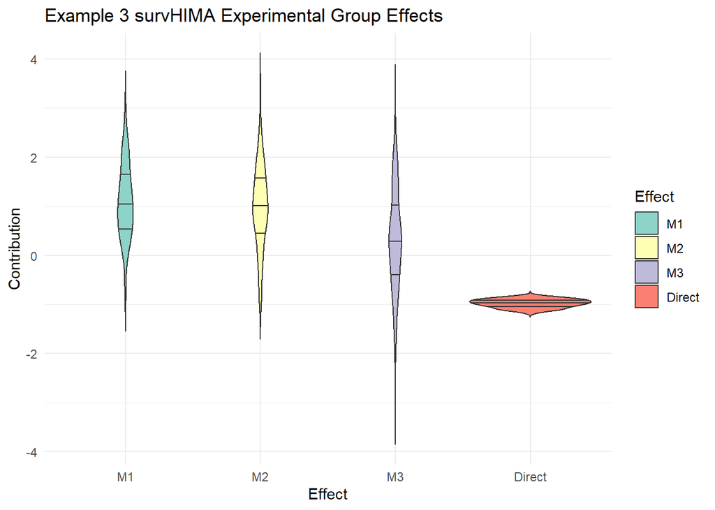

```r
E3survhima_experimental_pl
```

In the experimental group, the mean contributions of each effect are much higher than they are in the control group.

We are going to test for correlations between effects and the adjusted parametric Hazard Ratio.

*H<sub>0</sub>* : There exists no correlation between any effect and the adjusted hazard ratio

*H<sub>1</sub>* : There exists a correlation between any effect and the adjusted hazard ratio.

```r
E3survhima_effect_phr_cor <- perform_cor_tests(E3survhima, x = c(survHIMA.fit[,"Index"], "Direct"), y = "Adjusted", alternative = "two.sided", method = "spearman")
E3survhima_effect_phr_cor
```

```
## $`M1 - Adjusted`
##
##  Spearman's rank correlation rho
##
## data:  data[, name] and data[, y]
## S = 411358, p-value < 2.2e-16
## alternative hypothesis: true rho is not equal to 0
## sample estimates:
##       rho
## 0.6914738
##
##
## $`M2 - Adjusted`
##
##  Spearman's rank correlation rho
##
## data:  data[, name] and data[, y]
## S = 608568, p-value < 2.2e-16
## alternative hypothesis: true rho is not equal to 0
## sample estimates:
##       rho
## 0.5435626
##
##
## $`M3 - Adjusted`
##
##  Spearman's rank correlation rho
##
## data:  data[, name] and data[, y]
## S = 542858, p-value < 2.2e-16
## alternative hypothesis: true rho is not equal to 0
## sample estimates:
##       rho
## 0.5928463
##
##
## $`Direct - Adjusted`
##
##  Spearman's rank correlation rho
##
## data:  data[, name] and data[, y]
## S = 1731792, p-value = 1.716e-05
## alternative hypothesis: true rho is not equal to 0
## sample estimates:
##        rho
## -0.2988767
```

We can reject the null hypothesis(adjusted p < 0.05). For all mediator effects, there exists positive correlation to the parametric Hazard Ratio. The direct effect has negative correlation with the hazard ratio(adjusted p < 0.05). We shall move on to testing for correlation between time and adjusted hazard ratio.

*H<sub>0</sub>* : There exists no correlation between Time and Hazard Ratio.

*H<sub>1</sub>* : There exists a correlation between Time and Hazard Ratio.

```r
E3survhima_phr_time_cor <- perform_cor_tests(E3survhima, x = "Adjusted", y = "Time", alternative = "two.sided", method = "spearman")
E3survhima_phr_time_cor
```

```
## $`Adjusted - Time`
##
##  Spearman's rank correlation rho
##
## data:  data[, name] and data[, y]
## S = 2323684, p-value < 2.2e-16
## alternative hypothesis: true rho is not equal to 0
## sample estimates:
##        rho
## -0.7428066
```

We can reject the null hypothesis(p < 0.05). We shall move on to testing for correlation between time and all effects.

*H<sub>0</sub>* : There exists no correlation between any effect and survival time.

*H<sub>1</sub>* : There exists a correlation between any effect and survival time.

```r
E3survhima_effect_time_cor <- perform_cor_tests(E3survhima, x = c(survHIMA.fit[,"Index"], "Direct"), y = "Time", alternative = "two.sided", method = "spearman")
E3survhima_effect_time_cor
```

```
## $`M1 - Time`
##
##  Spearman's rank correlation rho
##
## data:  data[, name] and data[, y]
## S = 2120348, p-value < 2.2e-16
## alternative hypothesis: true rho is not equal to 0
## sample estimates:
##        rho
## -0.5903008
##
##
## $`M2 - Time`
##
##  Spearman's rank correlation rho
##
## data:  data[, name] and data[, y]
## S = 1969396, p-value < 2.2e-16
## alternative hypothesis: true rho is not equal to 0
## sample estimates:
##        rho
## -0.4770839
##
##
## $`M3 - Time`
##
##  Spearman's rank correlation rho
##
## data:  data[, name] and data[, y]
## S = 2003868, p-value < 2.2e-16
## alternative hypothesis: true rho is not equal to 0
## sample estimates:
##        rho
## -0.5029386
##
##
## $`Direct - Time`
##
##  Spearman's rank correlation rho
##
## data:  data[, name] and data[, y]
## S = 648180, p-value = 7.156e-15
## alternative hypothesis: true rho is not equal to 0
## sample estimates:
##       rho
## 0.5138528
```

We can reject the null hypothesis(adjusted p < 0.05). For all mediators, there exists negative correlation with time. The direct effect has positive correlation with time. We shall move on to testing for correlation between age and all effects.

```r
E3survhima_effect_age_cor <- perform_cor_tests(E3survhima, x = c(survHIMA.fit[,"Index"], "Direct"), y = "Age", alternative = "two.sided", method = "spearman")
E3survhima_effect_age_cor
```

```
## $`M1 - Age`
##
##  Spearman's rank correlation rho
##
## data:  data[, name] and data[, y]
## S = 1110763, p-value = 0.01817
## alternative hypothesis: true rho is not equal to 0
## sample estimates:
##       rho
## 0.1669067
##
##
## $`M2 - Age`
##
##  Spearman's rank correlation rho
##
## data:  data[, name] and data[, y]
## S = 1097050, p-value = 0.01207
## alternative hypothesis: true rho is not equal to 0
## sample estimates:
##      rho
## 0.177192
##
##
## $`M3 - Age`
##
##  Spearman's rank correlation rho
##
## data:  data[, name] and data[, y]
## S = 1398356, p-value = 0.4926
## alternative hypothesis: true rho is not equal to 0
## sample estimates:
##         rho
## -0.04879297
##
##
## $`Direct - Age`
##
##  Spearman's rank correlation rho
##
## data:  data[, name] and data[, y]
## S = 1090430, p-value = 0.009835
## alternative hypothesis: true rho is not equal to 0
## sample estimates:
##       rho
## 0.1821572
```

We can reject the null hypothesis(adjusted p < 0.05). There exists positive correlation with age to the direct effect and M2.

##### Test for differences across groups

We are going to use the Kruskal-Wallis test to determine the difference in variance for effects, hazard ratio, and time across sexes.

*H<sub>0</sub>* : There exists no difference in medians in any effects, hazard ratio, or time odds across male and female subjects.

*H<sub>1</sub>* : There exists a difference in medians in any effects, hazard ratio, or time across male and female subjects.

```r
E3survhima_kruskal_sex <- perform_kruskal(E3survhima, "Sex", c(survHIMA.fit[,"Index"], "Direct", "Adjusted","Time"))
```

```
## [1] "M1"
## [1] "M2"
## [1] "M3"
## [1] "Direct"
## [1] "Adjusted"
## [1] "Time"
```

```r
E3survhima_kruskal_sex
```

```
## $M1
##
##  Kruskal-Wallis rank sum test
##
## data:  y_val by x_val
## Kruskal-Wallis chi-squared = 0.0050229, df = 1, p-value = 0.9435
##
##
## $M2
##
##  Kruskal-Wallis rank sum test
##
## data:  y_val by x_val
## Kruskal-Wallis chi-squared = 1.1458, df = 1, p-value = 0.2844
##
##
## $M3
##
##  Kruskal-Wallis rank sum test
##
## data:  y_val by x_val
## Kruskal-Wallis chi-squared = 1.8998, df = 1, p-value = 0.1681
##
##
## $Direct
##
##  Kruskal-Wallis rank sum test
##
## data:  y_val by x_val
## Kruskal-Wallis chi-squared = 5.1387, df = 1, p-value = 0.0234
##
##
## $Adjusted
##
##  Kruskal-Wallis rank sum test
##
## data:  y_val by x_val
## Kruskal-Wallis chi-squared = 0.11874, df = 1, p-value = 0.7304
##
##
## $Time
##
##  Kruskal-Wallis rank sum test
##
## data:  y_val by x_val
## Kruskal-Wallis chi-squared = 0.051656, df = 1, p-value = 0.8202
```

The null hypothesis can be rejected. There exists a statistically significant difference in medians for the direct effect across male and female subjects.

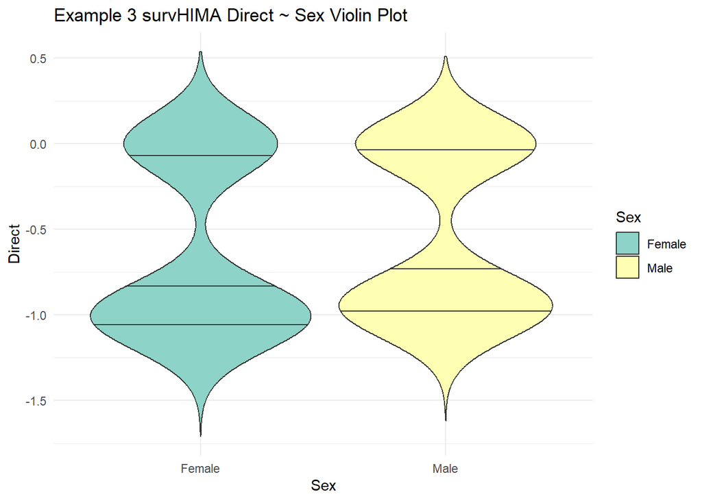

```r
E3survhima$Sex <- ifelse(E3survhima$Sex == 0, "Male", "Female")
E3survhima_sex_pl <- plot_violins(E3survhima, "Sex", "Direct", plotname = "Example 3 survHIMA Direct ~ Sex Violin Plot")
E3survhima_sex_pl
```

```r
boot_tests(E3survhima, "Sex", "Direct", mean)
```

```
##              2.5%      97.5%
## Female -0.7181047 -0.5176044
## Male   -0.6288492 -0.4461680
```

Females have increased sensitivity to the direct effect of the Treatment.

##### Findings

The results of **survHIMA** for Example 3 show:

The values for each effect are not normally distributed.

There exists positive correlation between M1 to M2 and M1 to M3.

There exists positive correlation with all mediator effects and hazard ratio.

There exists positive correlation with age to M2 and the direct effect.

Females have increased sensitivity to the direct effect of the treatment.

## Example 4 Data Overview

### Dimensions of the Data

```r
dim(Example4$PhenoData)
```

```
## [1] 100   4
```

```r
dim(Example4$Mediator)
```

```
## [1] 100 100
```

### Data Overview

Numerical Features

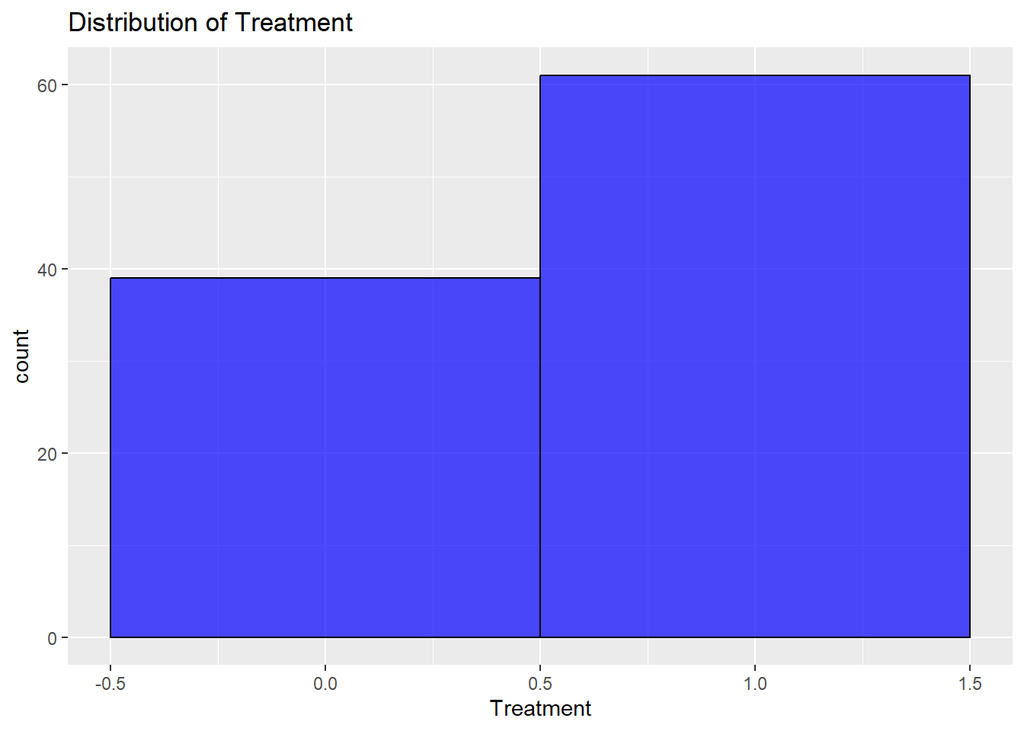

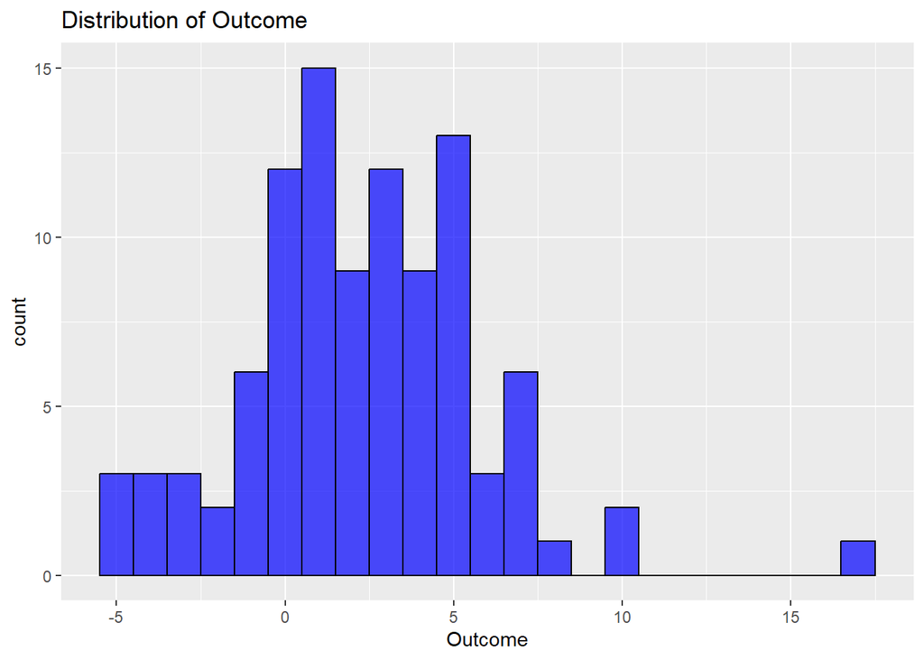

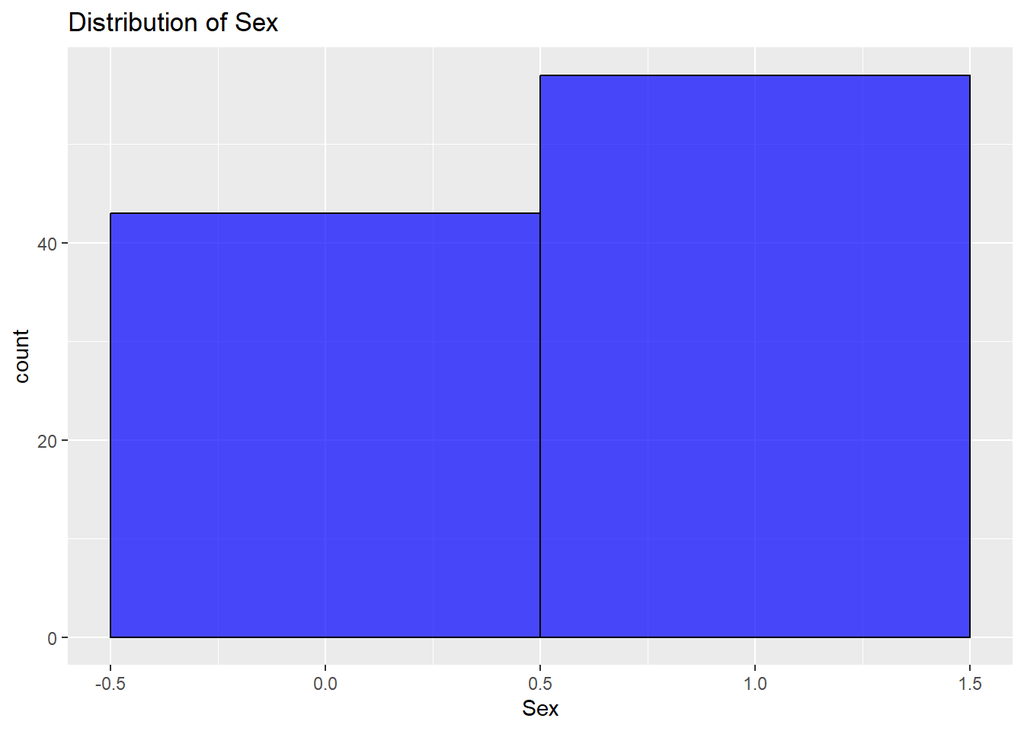

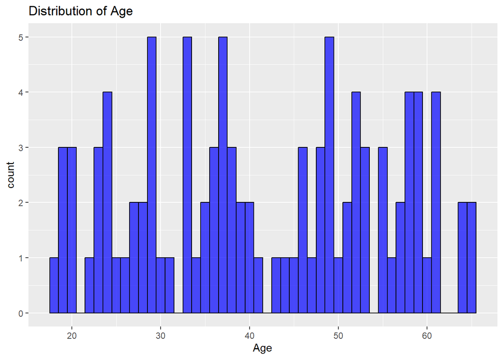

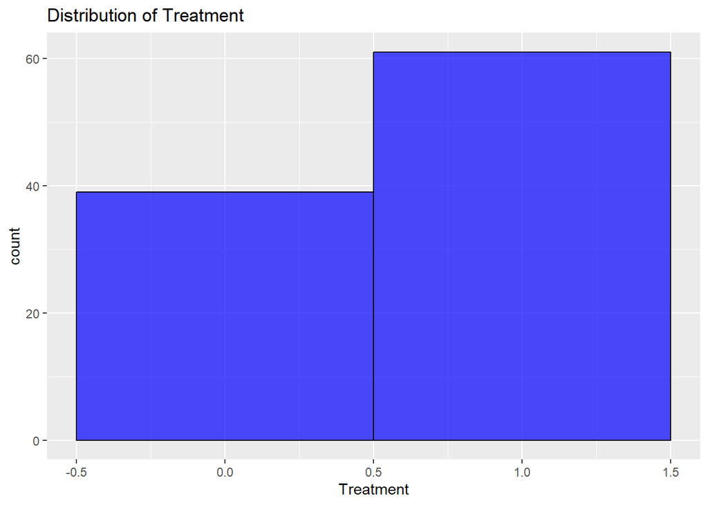

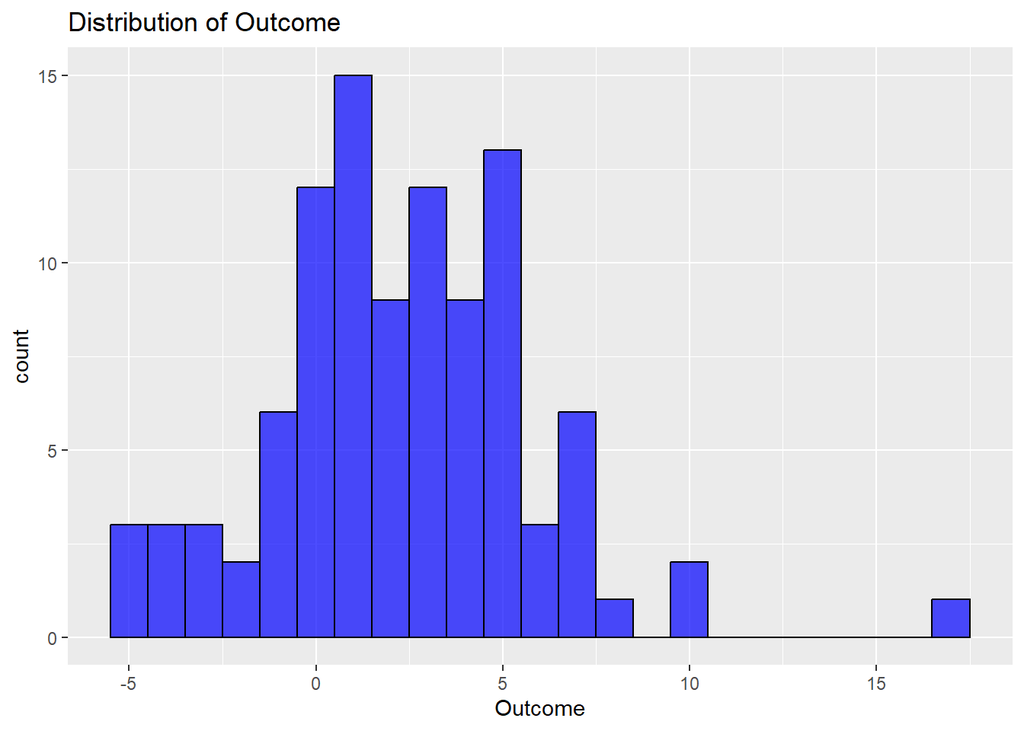

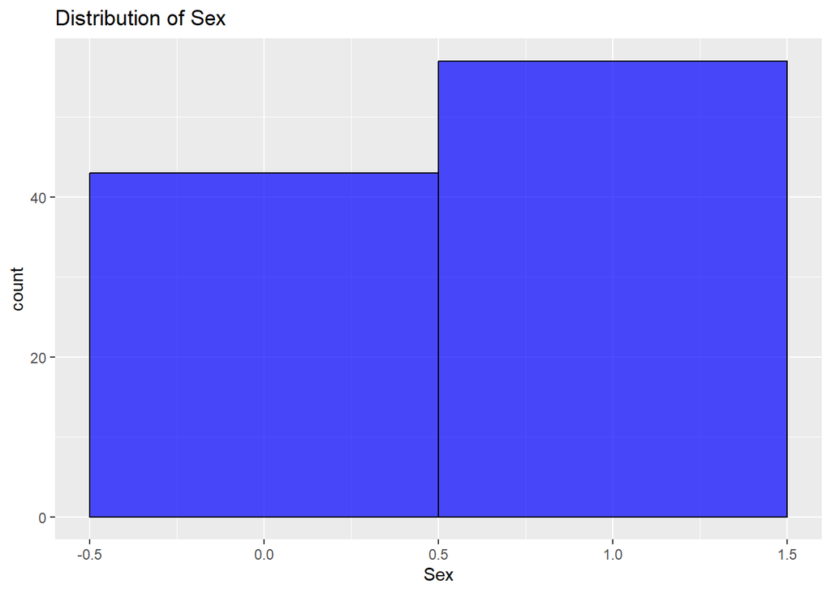

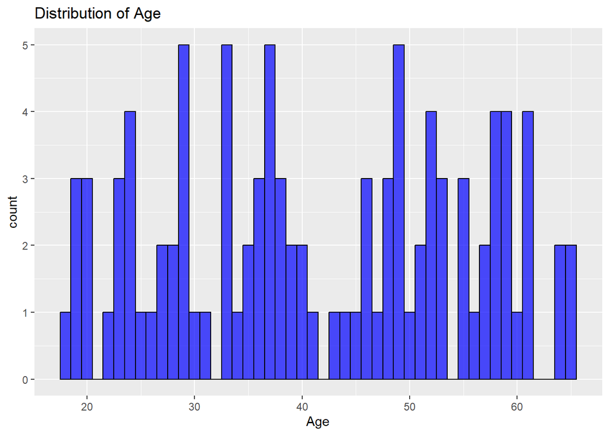

```r
# Histograms for numerical features
num_vars <- sapply(Example4$PhenoData, is.numeric)
data_numeric <- Example4$PhenoData[, num_vars]
lapply(names(data_numeric), function(var) {
  print(ggplot(Example4$PhenoData, aes_string(x = var)) +
        geom_histogram(binwidth = 1, fill = "blue", color = "black", alpha = 0.7) +
        labs(title = paste("Distribution of", var)))
})
```

```r
summary(Example4$PhenoData)
```

```
##    Treatment       Outcome              Sex            Age
##  Min.   :0.00   Min.   :-5.26081   Min.   :0.00   Min.   :18.00
##  1st Qu.:0.00   1st Qu.: 0.03439   1st Qu.:0.00   1st Qu.:29.00
##  Median :1.00   Median : 1.92975   Median :1.00   Median :40.00
##  Mean   :0.61   Mean   : 2.27495   Mean   :0.57   Mean   :41.54
##  3rd Qu.:1.00   3rd Qu.: 4.55644   3rd Qu.:1.00   3rd Qu.:53.00
##  Max.   :1.00   Max.   :16.57145   Max.   :1.00   Max.   :65.00
```

**Treatment**: A binary feature that indicates the presence of the treatment for a test subject. **1** indicates the presence of the treatment. **0** indicates the absence of the treatment.

**Outcome**: A continuous numerical feature with unknown units of measurement.

**Sex**: A binary feature that indicates the biological sex of the subject. **1** indicates females, and **0** indicates males.

**Age**: A continuous numerical features that represents the age of the subject in years.

Categorical Features

```r
# Bar plots for categorical features
cat_vars <- sapply(Example2$PhenoData, is.factor)
data_categorical <- Example2$PhenoData[, cat_vars, drop = FALSE]
lapply(names(data_categorical), function(var) {
  print(ggplot(Example2$PhenoData, aes_string(x = var)) +
        geom_bar(fill = "blue", color = "black", alpha = 0.7) +
        labs(title = paste("Frequency of", var)))
})
```

```
## list()
```

### Example 4 Prediction Model

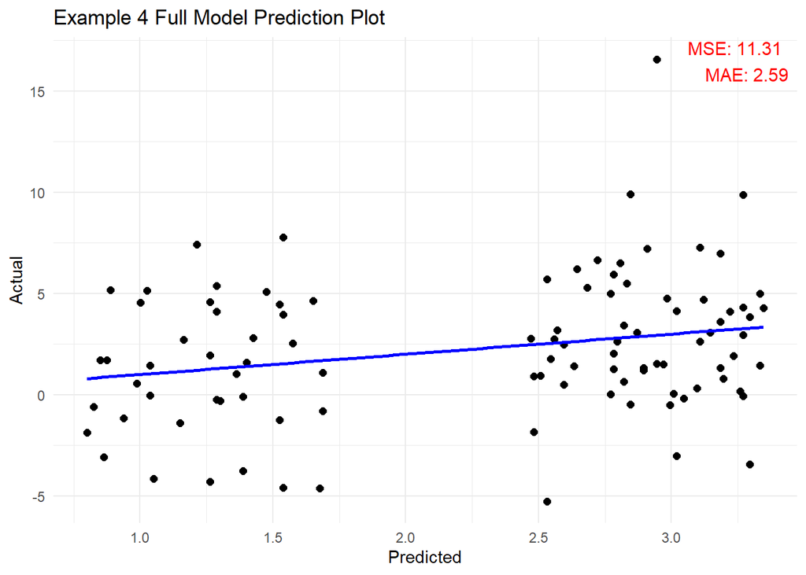

```r
plot_examples(Example4$PhenoData, plotname = "Example 4 Full Model Prediction Plot")
```

Clearly, the presence of treatment in conjunction with covariates do not accurately describe the relationship the presence of treatment has with the outcome. Mediation analysis must be performed to remedy this.

### Mediation Analysis with microHIMA

#### Mediator Identification

```r
head(himaDat$Example4$PhenoData)
microHIMA.fit <- microHIMA(
  X = himaDat$Example4$PhenoData$Treatment,
  Y = himaDat$Example4$PhenoData$Outcome,
  OTU = himaDat$Example4$Mediator,
  COV = himaDat$Example4$PhenoData[, c("Sex", "Age")],
  FDRcut = 0.05,
  verbose = TRUE
)
microHIMA.fit
summary(Example4$Mediator[,microHIMA.fit[,"Index"])
```

[output not shown]

**alpha_hat** represents the effect the treatment has on the mediators.

**beta_hat** represents the effect the mediators have towards the outcome.

**IDE** stands for “Indirect Effect”, and is the result of **alpha_hat*beta_hat**.

**rimp** stands for “Relative Importance” and represents the average percent contribution a mediator has towards the net Indirect Effect.

```r
E4micro <- estimatedEffects(fit = microHIMA.fit,
                            betas = microHIMA.fit[,"beta_hat"],
                            dat = himaDat$Example4,
                            X = himaDat$Example4$PhenoData$Treatment,
                            Y = himaDat$Example4$PhenoData$Outcome,
                            Cov = himaDat$Example4$PhenoData[, c("Sex", "Age")]
                            )
```

```
## Error: object 'microHIMA.fit' not found
```

```r
E4micropl <- plot_mediator_adjustments(actual = himaDat$Example4$PhenoData$Outcome,
                             estimations = E4micro,
                             mediator_indices = microHIMA.fit[,"Index"],
                             plotname = "Example Four Microbiome HIMA Outcome Predictions")
```

```
## Error in h(simpleError(msg, call)): error in evaluating the argument 'x' in selecting a method for function 'rowSums': object 'E4micro' not found
```

```r
E4micropl
```

```
## Error: object 'E4micropl' not found
```

The contribution towards the outcome by each mediator is calculated as **M * beta_hat.**

The contribution towards the outcome by the Direct Effect is calculated as the **E(Y | X, Cov) - IDE**.

The mediator adjusted prediction is **E(Y | X, M, Cov) = 𝛽*M + E(Y | X, Cov) - IDE**.

#### Effect Analysis

##### Test for Normality

*H<sub>0</sub>* : The values for every type of measured effect are drawn from the normal distribution.

*H<sub>1</sub>* : The values for every type of measured effect are drawn from outside the normal distribution.

```r
E4micro_control_ks_results <- kstests(dat = E4micro[E4micro$Treatment == 0,], exclude = c("Treatment","Sex","Other", "DominantEffect", "Direct"))
```

```
## Error: object 'E4micro' not found
```

```r
print(data.frame(E4micro_control_ks_results))
```

```
## Error in h(simpleError(msg, call)): error in evaluating the argument 'x' in selecting a method for function 'print': object 'E4micro_control_ks_results' not found
```

```r
E4micro_experimental_ks_results <- kstests(dat = E4micro[E4micro$Treatment != 0,], exclude = c("Treatment","Sex","Other", "DominantEffect", "Direct"))
```

```
## Error: object 'E4micro' not found
```

```r
print(data.frame(E4micro_experimental_ks_results))
```

```
## Error in h(simpleError(msg, call)): error in evaluating the argument 'x' in selecting a method for function 'print': object 'E4micro_experimental_ks_results' not found
```

##### Tests for Correlation

*H<sub>0</sub>* : There exists no correlation between a mediator effect and any other mediator effect.

*H<sub>1</sub>* : There exists a correlation between an effect and any other mediator effect.

```r
E4micro_effect_cor <- perform_cor_tests(E4micro, c(microHIMA.fit[,"Index"]), alternative = "two.sided", method = "spearman")
```

```
## Error: object 'microHIMA.fit' not found
```

```r
E4micro_effect_cor
```

```
## Error: object 'E4micro_effect_cor' not found
```

*H<sub>0</sub>* : There exists no correlation between an effect and any other effect in the experimental group.

*H<sub>1</sub>* : There exists a correlation between an effect and any other effect in the experimental group.

```r
E4micro_effect_cor_e <- perform_cor_tests(E4micro[E4micro$Treatment != 0,], c(microHIMA.fit[,"Index"], "Direct"), alternative = "two.sided", method = "spearman")
```

```
## Error: object 'microHIMA.fit' not found
```

```r
E4micro_effect_cor_e
```

```
## Error: object 'E4micro_effect_cor_e' not found
```

```r
E4micro_control_long <- melt(E4micro[E4micro$Treatment == 0,microHIMA.fit[,"Index"]], variable.name = "Effect", value.name = "Contribution")
```

```
## Error: object 'E4micro' not found
```

```r
head(E4micro_control_long)
```

```
## Error in h(simpleError(msg, call)): error in evaluating the argument 'x' in selecting a method for function 'head': object 'E4micro_control_long' not found
```

```r
E4micro_control_pl <- plot_violins(E4micro_control_long, x = "Effect", y = "Contribution", "Example 4 Microbiome HIMA Control Group Effects")
```

```
## Error: object 'E4micro_control_long' not found
```

```r
E4micro_control_boot <- boot_tests(data = E4micro_control_long, x = "Effect", y = "Contribution", statistic = mean)
```

```
## Error: object 'E4micro_control_long' not found
```

```r
E4micro_control_boot
```

```
## Error: object 'E4micro_control_boot' not found
```

```r
E4micro_control_pl
```

```
## Error: object 'E4micro_control_pl' not found
```

```r
E4micro_experimental_long <- melt(E4micro[E4micro$Treatment != 0,c(microHIMA.fit[,"Index"], "Direct")], variable.name = "Effect", value.name = "Contribution")
```

```
## Error: object 'E4micro' not found
```

```r
head(E4micro_experimental_long)
```

```
## Error in h(simpleError(msg, call)): error in evaluating the argument 'x' in selecting a method for function 'head': object 'E4micro_experimental_long' not found
```

```r
E4micro_experimental_pl <- plot_violins(E4micro_experimental_long, x = "Effect", y = "Contribution", "Example 4 Microbiome HIMA Experimental Group Effects")
```

```
## Error: object 'E4micro_experimental_long' not found
```

```r
E4micro_experimental_boot <- boot_tests(data = E4micro_experimental_long, x = "Effect", y = "Contribution", statistic = mean)
```

```
## Error: object 'E4micro_experimental_long' not found
```

```r
E4micro_experimental_boot
```

```
## Error: object 'E4micro_experimental_boot' not found
```

We are going to test for correlations between effects and the measured outcome and residuals of the mediator adjusted prediction to the measured outcome.

*H<sub>0</sub>* : There exists no correlation between any effect or the residuals and measured outcome.

*H<sub>1</sub>* : There exists a correlation between any effect or the residuals and measured outcome.

```r
E4micro_effect_outcome_cor <- perform_cor_tests(E4micro, x = c(microHIMA.fit[,"Index"], "Direct", "Residuals"), y = "Outcome", alternative = "two.sided", method = "spearman")
```

```
## Error: object 'microHIMA.fit' not found
```

```r
E4micro_effect_outcome_cor
```

```
## Error: object 'E4micro_effect_outcome_cor' not found
```

*H<sub>0</sub>* : There exists no correlation between any effect and age.

*H<sub>1</sub>* : There exists a correlation between any effect and age.

```r
E4micro_effect_age_cor <- perform_cor_tests(E4micro, x = c(microHIMA.fit[,"Index"], "Direct", "Residuals"), y = "Age", alternative = "two.sided", method = "spearman")
```

```
## Error: object 'microHIMA.fit' not found
```

```r
E4micro_effect_age_cor
```

```
## Error: object 'E4micro_effect_age_cor' not found
```

##### Test for differences across groups

We are going to use the Kruskal-Wallis test to determine the difference in variance for effects, residuals, and the outcome across sexes.

*H<sub>0</sub>* : There exists no difference in medians in any effects and the outcome across male and female subjects.

*H<sub>1</sub>* : There exists a difference in medians in any effects and the outcome across male and female subjects.

```r
E4micro_kruskal_sex <- perform_kruskal(E4micro, "Sex", c(microHIMA.fit[,"Index"], "Direct", "Outcome", "Residuals"))
```

```
## Error: object 'microHIMA.fit' not found
```

```r
E4micro_kruskal_sex
```

```
## Error: object 'E4micro_kruskal_sex' not found
```

```r
E4micro$Sex <- ifelse(E4micro$Sex == 0, "Male", "Female")
```

```
## Error: object 'E4micro' not found
```

```r
E4micro_sex_pl <- plot_violins(E4micro, "Sex", "Direct", plotname = "Example 4 Microbiome HIMA Direct ~ Sex Violin Plot")
```

```
## Error: object 'E4micro' not found
```

```r
E4micro_sex_pl
```

```
## Error: object 'E4micro_sex_pl' not found
```

```r
boot_tests(E4micro, "Sex", "Direct", mean)
```

```
## Error: object 'E4micro' not found
```

## Example 5 Data Overview

### Dimensions of the Data

```r
dim(Example5$PhenoData)
```

```
## [1] 300   4
```

```r
dim(Example5$Mediator)
```

```
## [1] 300 300
```

### Data Overview

Numerical Features

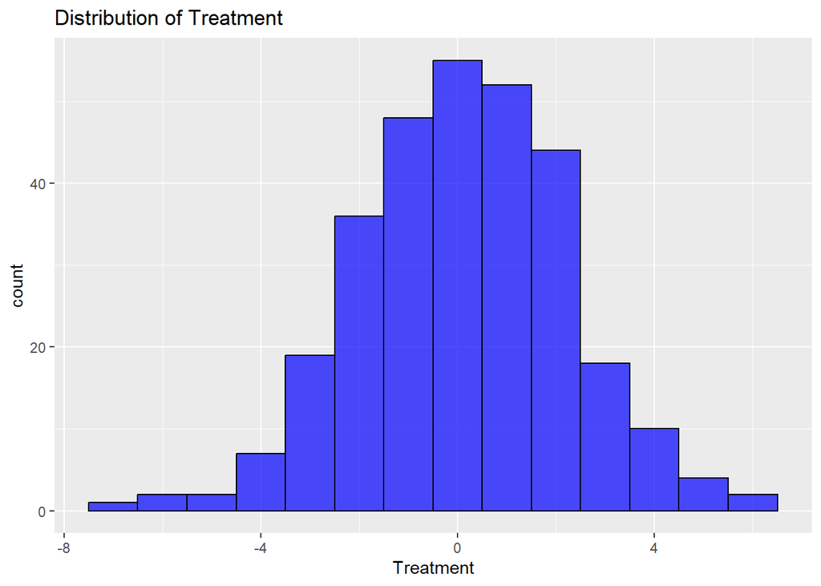

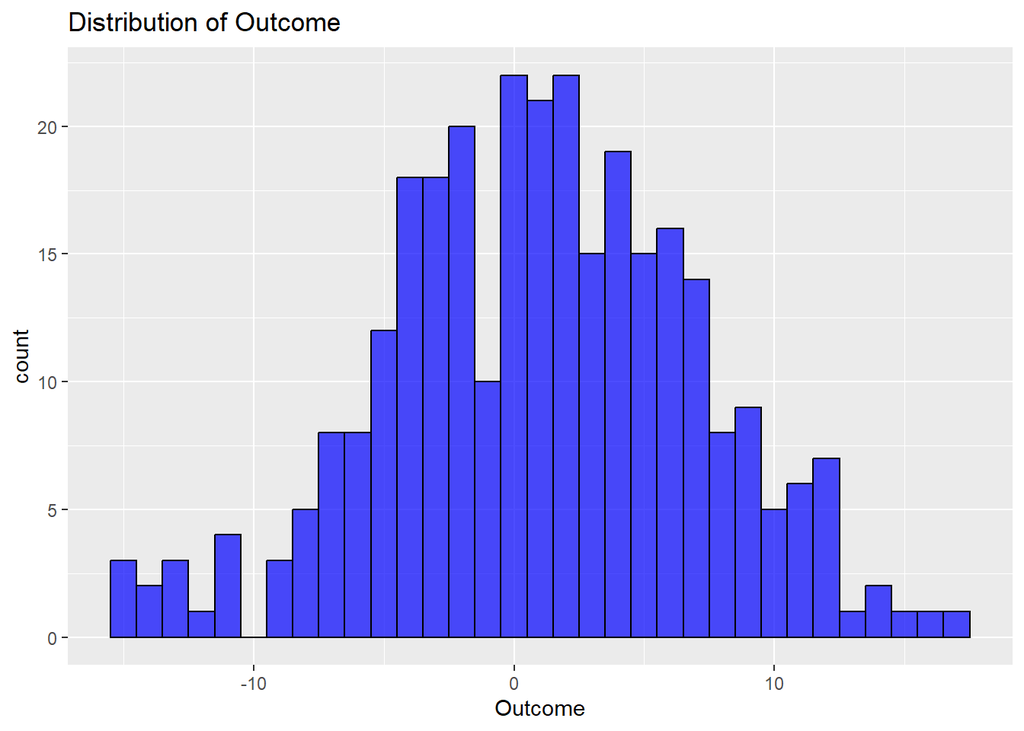

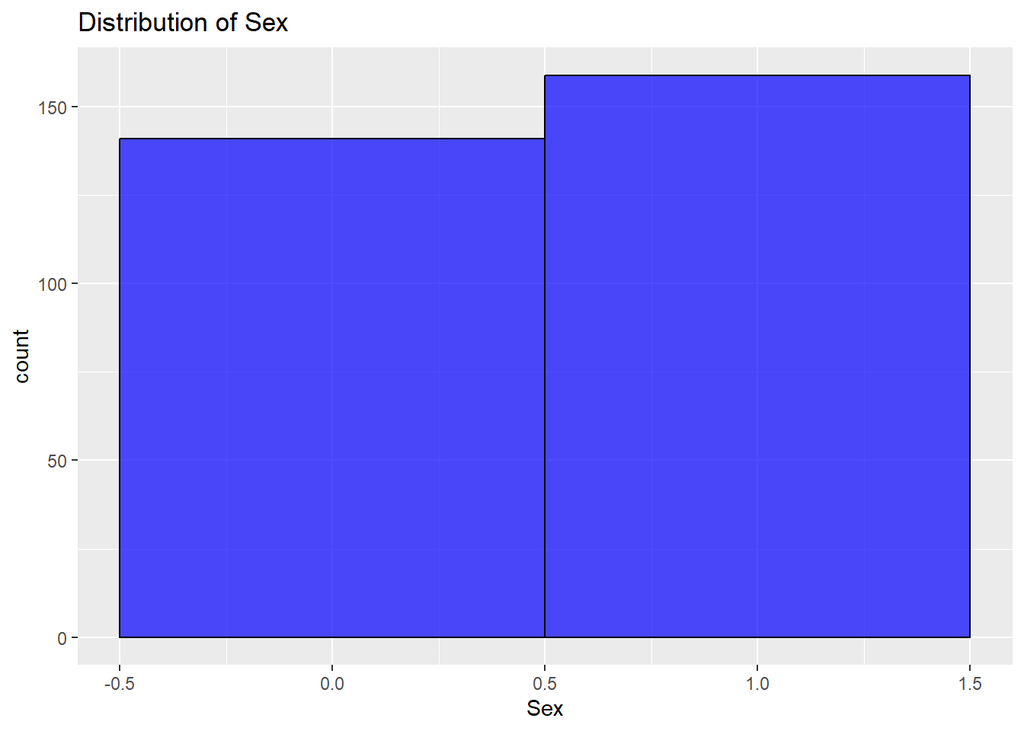

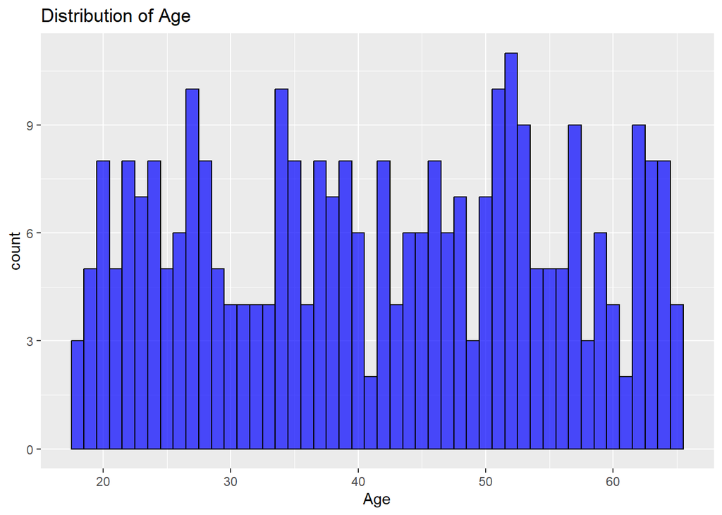

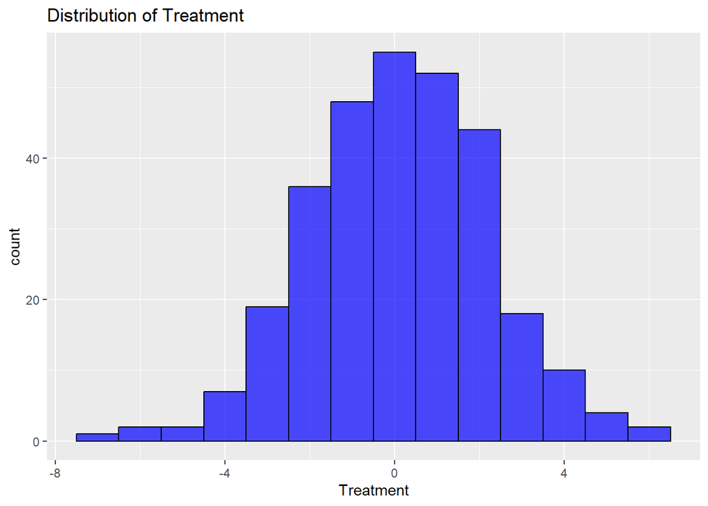

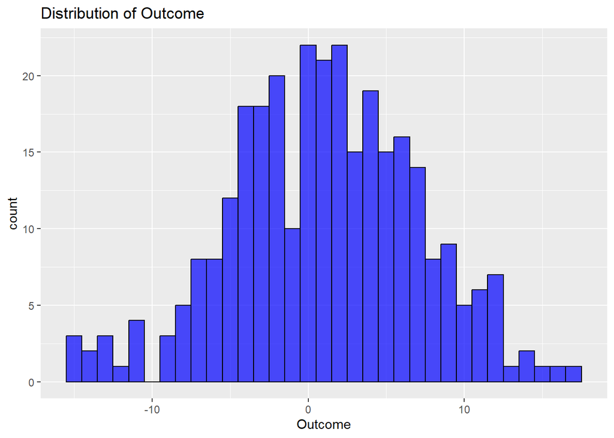

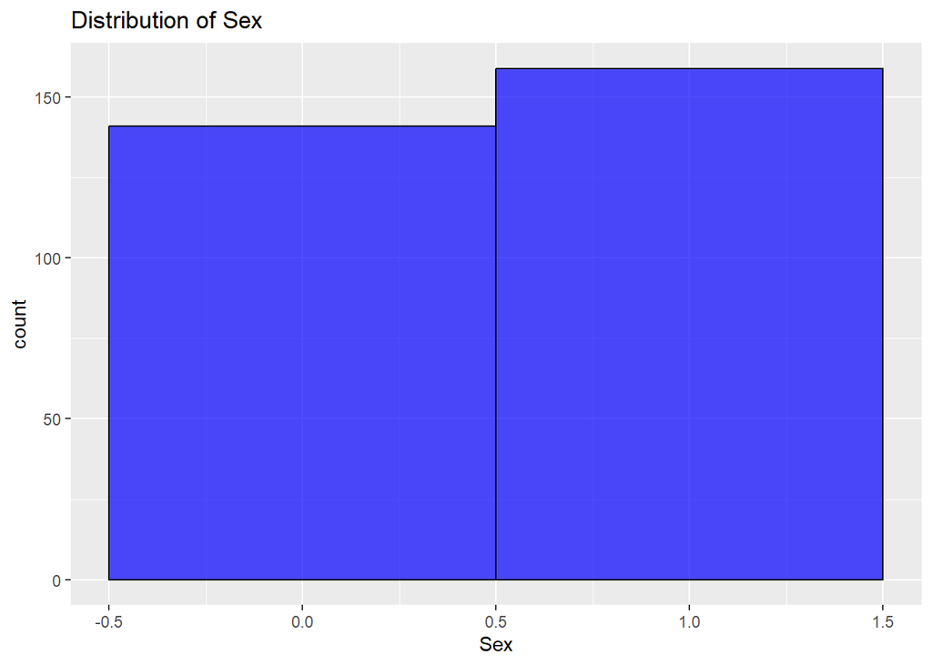

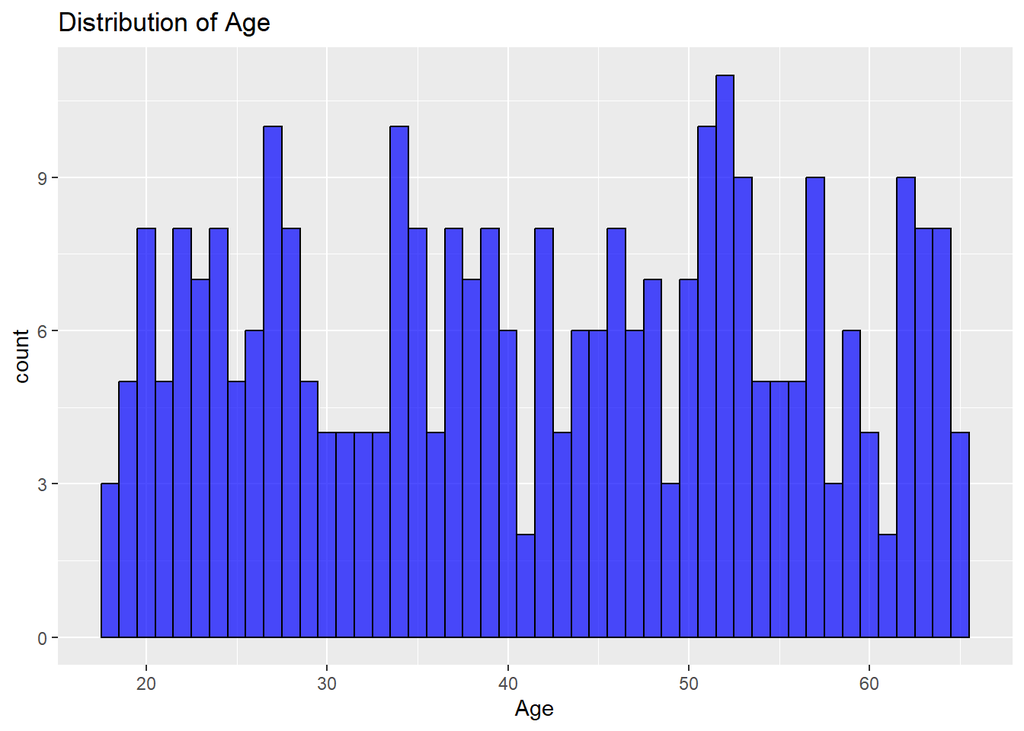

```r
# Histograms for numerical features
num_vars <- sapply(Example5$PhenoData, is.numeric)
data_numeric <- Example5$PhenoData[, num_vars]
lapply(names(data_numeric), function(var) {
  print(ggplot(Example5$PhenoData, aes_string(x = var)) +
        geom_histogram(binwidth = 1, fill = "blue", color = "black", alpha = 0.7) +
        labs(title = paste("Distribution of", var)))
})
```

```r
summary(Example5$Mediator)
```

[output not shown]

[output cut: 470 more lines]

[output not shown]

```r
summary(Example5$PhenoData)
```

```
##    Treatment           Outcome             Sex            Age
##  Min.   :-6.88402   Min.   :-15.326   Min.   :0.00   Min.   :18.00
##  1st Qu.:-1.28297   1st Qu.: -3.105   1st Qu.:0.00   1st Qu.:29.00
##  Median : 0.04826   Median :  1.038   Median :1.00   Median :42.00
##  Mean   : 0.09984   Mean   :  1.046   Mean   :0.53   Mean   :41.58
##  3rd Qu.: 1.53135   3rd Qu.:  5.212   3rd Qu.:1.00   3rd Qu.:53.00
##  Max.   : 6.18424   Max.   : 16.592   Max.   :1.00   Max.   :65.00
```

**Treatment**: The continuous exposure variable.

**Outcome**: A continuous numerical feature with unknown units of measurement.

**Sex**: A binary feature that indicates the biological sex of the subject. **1** indicates females, and **0** indicates males.

**Age**: A continuous numerical features that represents the age of the subject in years.

Categorical Features

```r
# Bar plots for categorical features
cat_vars <- sapply(Example2$PhenoData, is.factor)
data_categorical <- Example2$PhenoData[, cat_vars, drop = FALSE]
lapply(names(data_categorical), function(var) {
  print(ggplot(Example2$PhenoData, aes_string(x = var)) +
        geom_bar(fill = "blue", color = "black", alpha = 0.7) +
        labs(title = paste("Frequency of", var)))
})
```

```
## list()
```

### Example 5 Prediction Model

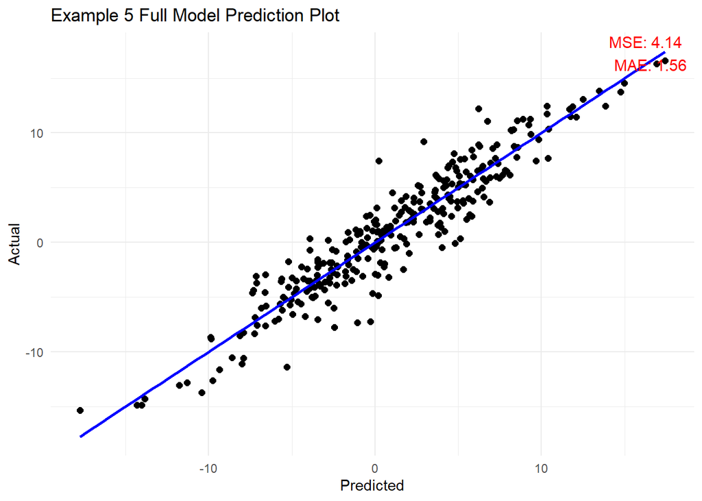

```r
plot_examples(Example5$PhenoData, plotname = "Example 5 Full Model Prediction Plot")
```

### Mediation Analysis with qHIMA

#### Mediator Identification

```r
qHIMA.fit <- qHIMA(
  X = himaDat$Example5$PhenoData$Treatment,
  M = himaDat$Example5$Mediator,
  Y = himaDat$Example5$PhenoData$Outcome,
  COV = himaDat$Example5$PhenoData[, c("Sex", "Age")],
  tau = c(0.3, 0.5, 0.7),
  scale = FALSE, # Disabled only for simulation data
  Bonfcut = 0.05,
  verbose = TRUE
)
```

```
## Running penalized quantile regression with tau = 0.3 ...     (3:04:58 PM)
```

```
## Step 1: Sure Independent Screening ...     (3:04:58 PM)
```

```
##         Top 106 mediators are selected: M1, M2, M3, M4, M8, M9, M10, M11, M12, M14, M16, M19, M20, M28, M29, M31, M32, M33, M34, M36, M39, M41, M43, M45, M46, M51, M53, M56, M58, M60, M62, M63, M69, M72, M86, M88, M92, M94, M95, M101, M104, M107, M110, M115, M122, M127, M138, M139, M143, M144, M1…
```

```
## Step 2: Penalized estimate (MCP) ...     (3:04:58 PM)
```

```
##         Adjusting for covariate(s): Sex, Age
```

```
## Step 3: Joint significance test ...     (3:05:00 PM)
```

```
##         3 significant mediator(s) identified.
```

```
## Running penalized quantile regression with tau = 0.5 ...     (3:05:01 PM)
```

```
## Step 1: Sure Independent Screening ...     (3:05:01 PM)
```

```
##         Top 106 mediators are selected: M1, M2, M3, M4, M5, M11, M12, M13, M14, M21, M25, M26, M28, M31, M32, M37, M39, M41, M42, M43, M46, M53, M59, M63, M65, M67, M69, M70, M72, M77, M79, M84, M90, M93, M94, M96, M98, M100, M101, M104, M105, M106, M107, M111, M112, M115, M130, M131, M133, M135,…
```

```
## Step 2: Penalized estimate (MCP) ...     (3:05:02 PM)
```

```
##         Adjusting for covariate(s): Sex, Age
```

```
## Step 3: Joint significance test ...     (3:05:03 PM)
```

```
##         3 significant mediator(s) identified.
```

```
## Running penalized quantile regression with tau = 0.7 ...     (3:05:04 PM)
```

```
## Step 1: Sure Independent Screening ...     (3:05:04 PM)
```

```
##         Top 106 mediators are selected: M1, M2, M3, M4, M11, M12, M13, M14, M15, M22, M25, M27, M29, M32, M37, M43, M47, M50, M52, M54, M55, M58, M60, M63, M67, M69, M70, M72, M76, M77, M78, M79, M82, M83, M84, M86, M90, M91, M93, M94, M96, M100, M101, M104, M105, M108, M109, M112, M114, M116, M1…
```

```
## Step 2: Penalized estimate (MCP) ...     (3:05:05 PM)
```

```
##         Adjusting for covariate(s): Sex, Age
```

```
## Step 3: Joint significance test ...     (3:05:06 PM)
```

```
##         3 significant mediator(s) identified.
```

```
## Done!     (3:05:08 PM)
```

```r
max_rimp <- aggregate(rimp ~ tau + Index, qHIMA.fit, max)
qHIMA.fit <- merge(qHIMA.fit, max_rimp)
qHIMA.fit <- qHIMA.fit[order(qHIMA.fit$tau),c("Index", "alpha_hat", "alpha_se", "beta_hat", "beta_se", "IDE", "rimp", "pmax", "tau")]
qHIMA.fit
```

```
##   Index  alpha_hat   alpha_se   beta_hat    beta_se       IDE     rimp
## 1    M1  0.7077073 0.02741520  1.0377102 0.07390250 0.7343950 34.13056
## 4    M2  0.7991857 0.02752990  0.6859180 0.09443574 0.5481758 25.47613
## 9    M3 -0.9359872 0.02681275 -0.9285939 0.11441906 0.8691521 40.39331
## 3    M1  0.7077073 0.02741520  1.0086785 0.07106676 0.7138491 37.63698
## 5    M2  0.7991857 0.02752990  0.6896749 0.08406094 0.5511783 29.06033
## 7    M3 -0.9359872 0.02681275 -0.6748401 0.09968828 0.6316417 33.30268
## 2    M1  0.7077073 0.02741520  0.9926598 0.10049852 0.7025125 35.37265
## 6    M2  0.7991857 0.02752990  0.7598478 0.11904613 0.6072595 30.57650
## 8    M3 -0.9359872 0.02681275 -0.7225111 0.10892512 0.6762612 34.05085
##           pmax tau
## 1 0.000000e+00 0.3
## 4 3.776979e-13 0.3
## 9 4.440892e-16 0.3
## 3 0.000000e+00 0.5
## 5 2.220446e-16 0.5
## 7 1.292255e-11 0.5
## 2 0.000000e+00 0.7
## 6 1.738774e-10 0.7
## 8 3.287104e-11 0.7
```

```r
summary(Example5$Mediator[,unique(qHIMA.fit[, "Index"])])
```

```
##        M1                M2                M3
##  Min.   :-4.5862   Min.   :-6.2546   Min.   :-5.6362
##  1st Qu.:-0.7819   1st Qu.:-0.9101   1st Qu.:-1.0945
##  Median : 0.5014   Median : 0.6121   Median : 0.3135
##  Mean   : 0.4860   Mean   : 0.4511   Mean   : 0.3431
##  3rd Qu.: 1.7012   3rd Qu.: 1.8169   3rd Qu.: 1.8751
##  Max.   : 5.4811   Max.   : 6.4851   Max.   : 6.8325
```

In the 30th quantile, M1, M2, and M3 have been identified as the top three most significant mediator variables. (p < 0.05)

In the 50th quantile, M1, M2, and M3 have been identified as the top three most significant mediator variables. (p < 0.05)

In the 70th quantile, M1, M2, and M3 have been identified as the top three most significant mediator variables. (p < 0.05)

**alpha_hat** represents the effect the treatment has on the mediators.

**beta_hat** represents the effect the mediators have towards the outcome.

**IDE** stands for “Indirect Effect”, and is the result of **alpha_hat*beta_hat**.

**rimp** stands for “Relative Importance” and represents the average percent contribution a mediator has towards the net Indirect Effect.

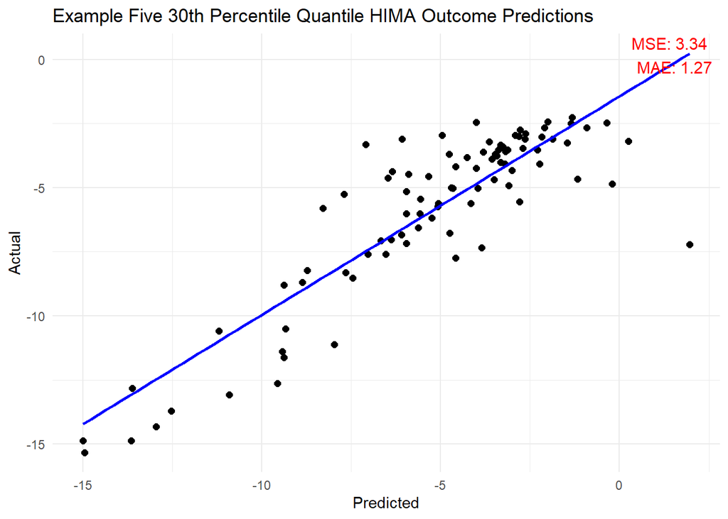

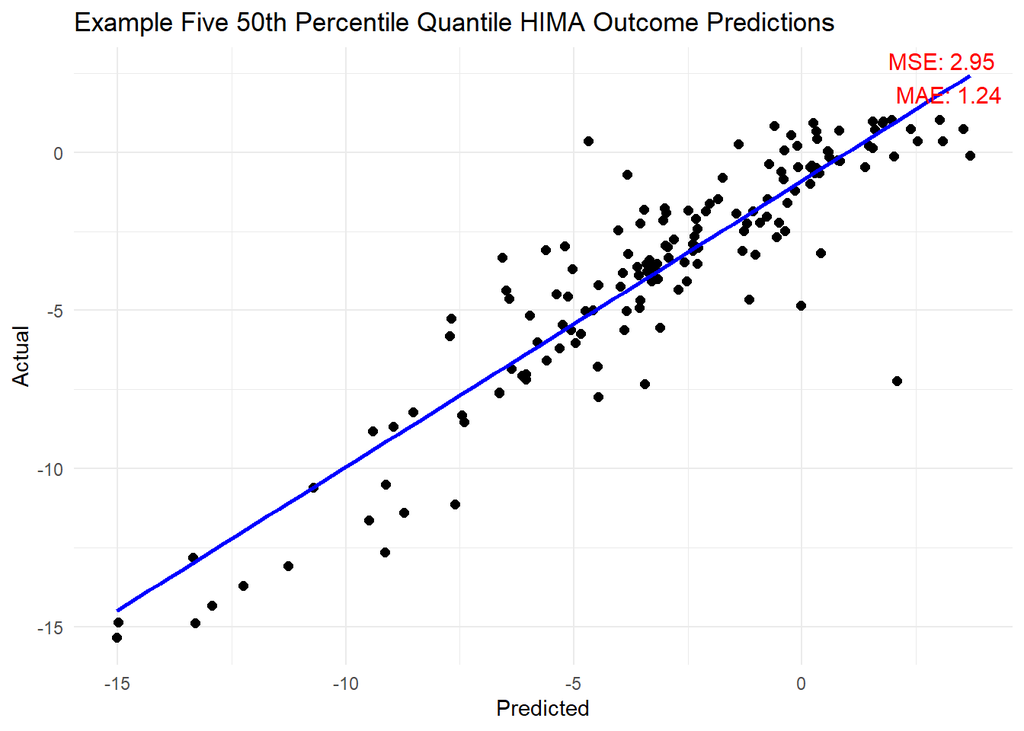

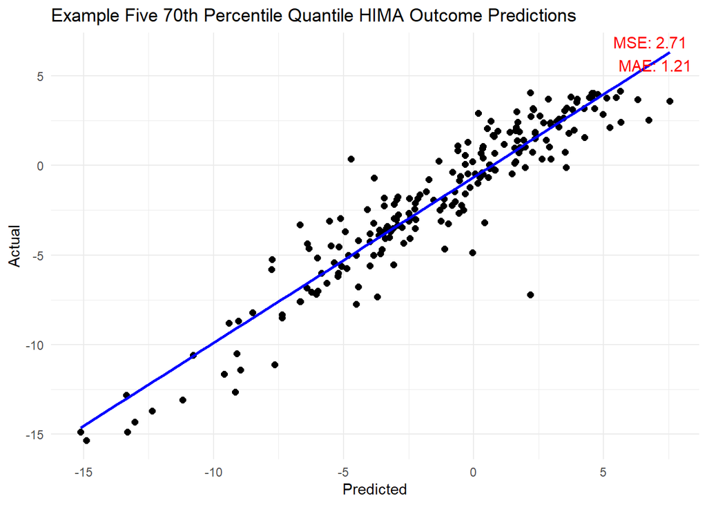

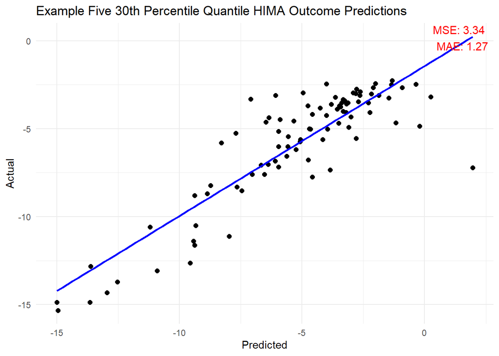

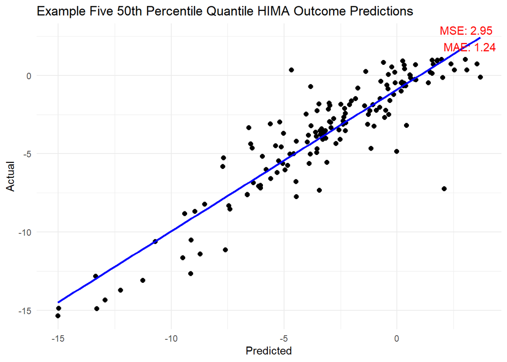

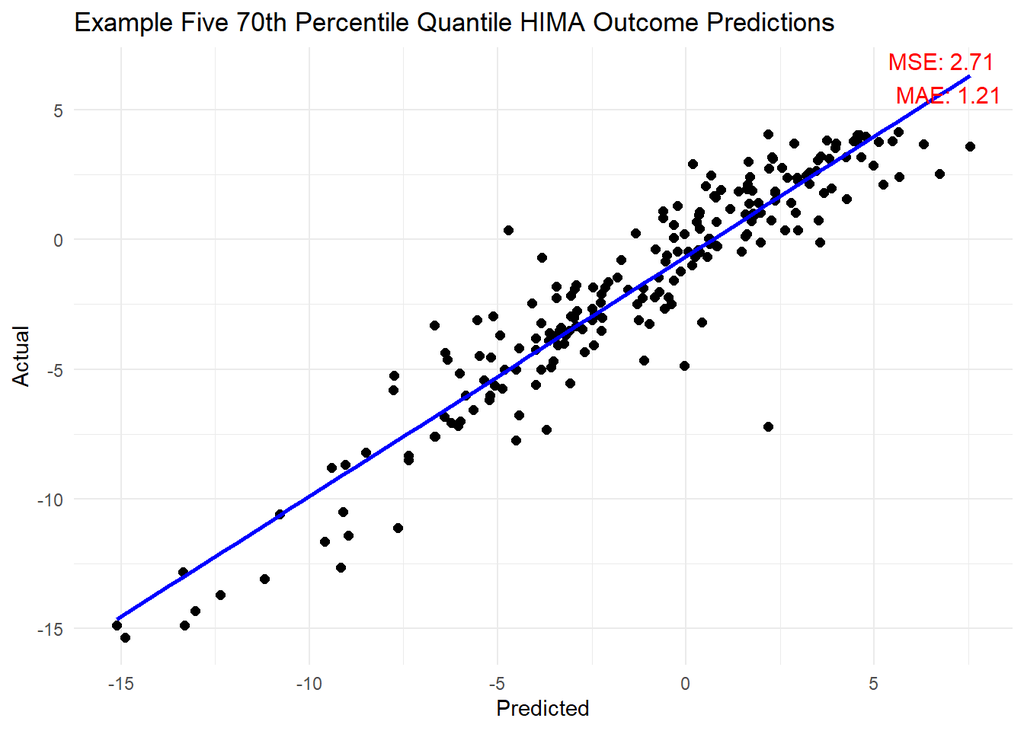

```r
E5qhima30th <- data.frame(estimatedEffects(fit = qHIMA.fit[qHIMA.fit$tau == 0.3,],
                              betas = qHIMA.fit[qHIMA.fit$tau == 0.3,"beta_hat"],
                              type = "continuous",
                              dat = himaDat$Example5,
                              X = himaDat$Example5$PhenoData$Treatment,
                              Y = himaDat$Example5$PhenoData$Outcome,
                              Cov = himaDat$Example5$PhenoData[, c("Sex", "Age")]))

E5qhima30th <- E5qhima30th[E5qhima30th$Outcome <= quantile(E5qhima30th$Outcome,0.3),]

E5qhima50th <- estimatedEffects(fit = qHIMA.fit[qHIMA.fit$tau == 0.5,],
                              betas = qHIMA.fit[qHIMA.fit$tau == 0.5,"beta_hat"],
                              type = "continuous",
                              dat = himaDat$Example5,
                              X = himaDat$Example5$PhenoData$Treatment,
                              Y = himaDat$Example5$PhenoData$Outcome,
                              Cov = himaDat$Example5$PhenoData[, c("Sex", "Age")])
E5qhima50th <- E5qhima50th[E5qhima50th$Outcome <= quantile(E5qhima50th$Outcome,0.5),]

E5qhima70th <- estimatedEffects(fit = qHIMA.fit[qHIMA.fit$tau == 0.7,],
                              betas = qHIMA.fit[qHIMA.fit$tau == 0.7,"beta_hat"],
                              type = "continuous",
                              dat = himaDat$Example5,
                              X = himaDat$Example5$PhenoData$Treatment,
                              Y = himaDat$Example5$PhenoData$Outcome,
                              Cov = himaDat$Example5$PhenoData[, c("Sex", "Age")])
E5qhima70th <- E5qhima70th[E5qhima70th$Outcome <= quantile(E5qhima70th$Outcome,0.7),]
E5qhima_pls <- list()
E5qhima_pls[["30th"]] <- plot_mediator_adjustments(actual = himaDat$Example5$PhenoData[himaDat$Example5$PhenoData$Outcome <= quantile(himaDat$Example5$PhenoData$Outcome, 0.3),]$Outcome,
                             estimations = E5qhima30th,
                             mediator_indices = qHIMA.fit[qHIMA.fit$tau == 0.3,"Index"],
                             plotname = "Example Five 30th Percentile Quantile HIMA Outcome Predictions")
E5qhima_pls[["50th"]] <- plot_mediator_adjustments(actual = (himaDat$Example5$PhenoData[himaDat$Example5$PhenoData$Outcome <= quantile(himaDat$Example5$PhenoData$Outcome, 0.5),]$Outcome),
                           estimations = E5qhima50th,
                           mediator_indices = qHIMA.fit[qHIMA.fit$tau == 0.5,"Index"],
                           plotname = "Example Five 50th Percentile Quantile HIMA Outcome Predictions")
E5qhima_pls[["70th"]] <- plot_mediator_adjustments(actual = (himaDat$Example5$PhenoData[himaDat$Example5$PhenoData$Outcome <= quantile(himaDat$Example5$PhenoData$Outcome, 0.7),]$Outcome),
                           estimations = E5qhima70th,
                           mediator_indices = qHIMA.fit[qHIMA.fit$tau == 0.7,"Index"],
                           plotname = "Example Five 70th Percentile Quantile HIMA Outcome Predictions")
lapply(names(E5qhima_pls), function(var) {
  print(E5qhima_pls[[var]])
})
```

The consideration of mediators allows the relationship between Treatment and Outcome to be more accurately described.

The contribution towards the outcome by each mediator is calculated as **M * beta_hat.**

The contribution towards the outcome by the Direct Effect is calculated as the **E(Y | X, Cov) - IDE**.

The mediator adjusted prediction is **E(Y | X, M, Cov) = 𝛽*M + E(Y | X, Cov) - IDE**.

#### Effect Analysis

##### Test for Normality

*H<sub>0</sub>* : The values for every type of measured effect are drawn from the normal distribution.

*H<sub>1</sub>* : The values for every type of measured effect are drawn from outside the normal distribution.

```r
E5qhima30th_ks_results <- kstests(dat = E5qhima30th, exclude = c("Sex","Other", "DominantEffect", "Direct"))
```

```
## [1] "Treatment" "Outcome"   "Age"       "M1"        "M2"        "M3"
## [7] "Residuals" "Adjusted"
```

```r
E5qhima50th_ks_results <- kstests(dat = E5qhima50th, exclude = c("Sex","Other", "DominantEffect", "Direct"))
```

```
## [1] "Treatment" "Outcome"   "Age"       "M1"        "M2"        "M3"
## [7] "Residuals" "Adjusted"
```

```r
E5qhima70th_ks_results <- kstests(dat = E5qhima70th, exclude = c("Sex","Other", "DominantEffect", "Direct"))
```

```
## [1] "Treatment" "Outcome"   "Age"       "M1"        "M2"        "M3"
## [7] "Residuals" "Adjusted"
```

```r
list(E5qhima30th_ks_results,E5qhima50th_ks_results,E5qhima70th_ks_results)
```

```
## [[1]]
##           D_Statistic      P_Value
## Treatment   0.6959779 6.661338e-16
## Outcome     0.9879998 6.661338e-16
## Age         1.0000000 1.342837e-78
## M1          0.4972816 6.661338e-16
## M2          0.4860526 6.661338e-16
## M3          0.6763409 6.661338e-16
## Residuals   0.2571187 9.809328e-06
## Adjusted    0.8691679 6.661338e-16
##
## [[2]]
##           D_Statistic       P_Value
## Treatment   0.4872855  2.314347e-31
## Outcome     0.6476386  4.502413e-55
## Age         1.0000000 1.029640e-130
## M1          0.3027758  2.275525e-12
## M2          0.2444037  3.299831e-08
## M3          0.4522583  4.489197e-27
## Residuals   0.2544991  7.282459e-09
## Adjusted    0.5855849  4.206327e-45
##
## [[3]]
##           D_Statistic       P_Value
## Treatment   0.2910951  6.995374e-16
## Outcome     0.4514481  1.337145e-37
## Age         1.0000000 7.894918e-183
## M1          0.1646620  2.266800e-05
## M2          0.1354658  8.989685e-04
## M3          0.3125800  3.013319e-18
## Residuals   0.2342062  1.975723e-10
## Adjusted    0.4140801  1.060885e-31
```

##### Tests for Correlation

We reject *H<sub>0</sub>* (p < 0.05). In rejection of the null hypothesis, we shall test for whether there exists correlations between each mediator effect.

*H<sub>0</sub>* : There exists no correlation between a mediator effect and any other mediator effect.

*H<sub>1</sub>* : There exists a correlation between an effect and any other mediator effect.

```r
E5qhima30th_effect_cor <- perform_cor_tests(E5qhima30th, c(qHIMA.fit[qHIMA.fit[,"tau"] == 0.3,"Index"], "Direct"), alternative = "two.sided", method = "spearman")
E5qhima50th_effect_cor <- perform_cor_tests(E5qhima50th, c(qHIMA.fit[qHIMA.fit[,"tau"] == 0.5,"Index"], "Direct"), alternative = "two.sided", method = "spearman")
E5qhima70th_effect_cor <- perform_cor_tests(E5qhima70th, c(qHIMA.fit[qHIMA.fit[,"tau"] == 0.7,"Index"], "Direct"), alternative = "two.sided", method = "spearman")

E5qhima30th_effect_cor
```

```
## $`M1 - M2`
##
##  Spearman's rank correlation rho
##
## data:  data[, x[i]] and data[, x[j]]
## S = 74468, p-value = 0.000184
## alternative hypothesis: true rho is not equal to 0
## sample estimates:
##      rho
## 0.387019
##
##
## $`M1 - M3`
##
##  Spearman's rank correlation rho
##
## data:  data[, x[i]] and data[, x[j]]
## S = 76092, p-value = 0.0003149
## alternative hypothesis: true rho is not equal to 0
## sample estimates:
##       rho
## 0.3736511
##
##
## $`M1 - Direct`
##
##  Spearman's rank correlation rho
##
## data:  data[, x[i]] and data[, x[j]]
## S = 70608, p-value = 4.694e-05
## alternative hypothesis: true rho is not equal to 0
## sample estimates:
##       rho
## 0.4187924
##
##
## $`M2 - M3`
##
##  Spearman's rank correlation rho
##
```

[output cut: 15 more lines]

```
## sample estimates:
##       rho
## 0.4886447
##
##
## $`M3 - Direct`
##
##  Spearman's rank correlation rho
##
## data:  data[, x[i]] and data[, x[j]]
## S = 71552, p-value = 6.636e-05
## alternative hypothesis: true rho is not equal to 0
## sample estimates:
##       rho
## 0.4110219
```

```r
E5qhima50th_effect_cor
```

```
## $`M1 - M2`
##
##  Spearman's rank correlation rho
##
## data:  data[, x[i]] and data[, x[j]]
## S = 248714, p-value < 2.2e-16
## alternative hypothesis: true rho is not equal to 0
## sample estimates:
##       rho
## 0.5578221
##
##
## $`M1 - M3`
##
##  Spearman's rank correlation rho
##
## data:  data[, x[i]] and data[, x[j]]
## S = 332358, p-value = 2.609e-07
## alternative hypothesis: true rho is not equal to 0
## sample estimates:
##       rho
## 0.4091151
##
##
## $`M1 - Direct`
##
##  Spearman's rank correlation rho
##
## data:  data[, x[i]] and data[, x[j]]
## S = 220678, p-value < 2.2e-16
## alternative hypothesis: true rho is not equal to 0
## sample estimates:
##       rho
## 0.6076661
##
##
## $`M2 - M3`
##
##  Spearman's rank correlation rho
##
```

[output cut: 15 more lines]

```
## sample estimates:
##      rho
## 0.683321
##
##
## $`M3 - Direct`
##
##  Spearman's rank correlation rho
##
## data:  data[, x[i]] and data[, x[j]]
## S = 213598, p-value < 2.2e-16
## alternative hypothesis: true rho is not equal to 0
## sample estimates:
##       rho
## 0.6202533
```

```r
E5qhima70th_effect_cor
```

```
## $`M1 - M2`
##
##  Spearman's rank correlation rho
##
## data:  data[, x[i]] and data[, x[j]]
## S = 521478, p-value < 2.2e-16
## alternative hypothesis: true rho is not equal to 0
## sample estimates:
##       rho
## 0.6621381
##
##
## $`M1 - M3`
##
##  Spearman's rank correlation rho
##
## data:  data[, x[i]] and data[, x[j]]
## S = 766832, p-value < 2.2e-16
## alternative hypothesis: true rho is not equal to 0
## sample estimates:
##      rho
## 0.503175
##
##
## $`M1 - Direct`
##
##  Spearman's rank correlation rho
##
## data:  data[, x[i]] and data[, x[j]]
## S = 452604, p-value < 2.2e-16
## alternative hypothesis: true rho is not equal to 0
## sample estimates:
##       rho
## 0.7067611
##
##
## $`M2 - M3`
##
##  Spearman's rank correlation rho
##
```

[output cut: 15 more lines]

```
## sample estimates:
##       rho
## 0.7362013
##
##
## $`M3 - Direct`
##
##  Spearman's rank correlation rho
##
## data:  data[, x[i]] and data[, x[j]]
## S = 480150, p-value < 2.2e-16
## alternative hypothesis: true rho is not equal to 0
## sample estimates:
##       rho
## 0.6889142
```

We will follow up testing for correlations between effects and the measured outcome and residuals of the mediator adjusted prediction to the measured outcome.

*H<sub>0</sub>* : There exists no correlation between any effect or the residuals to the outcome.

*H<sub>1</sub>* : There exists a correlation between any effect or the residuals to the outcome.

```r
E5qhima30th_effect_outcome_cor <- perform_cor_tests(E5qhima30th, c(qHIMA.fit[qHIMA.fit[,"tau"] == 0.3,"Index"], "Direct","Residuals"), "Outcome", alternative = "two.sided", method = "spearman")
E5qhima50th_effect_outcome_cor <- perform_cor_tests(E5qhima50th, c(qHIMA.fit[qHIMA.fit[,"tau"] == 0.5,"Index"], "Direct","Residuals"), "Outcome", alternative = "two.sided", method = "spearman")
E5qhima70th_effect_outcome_cor <- perform_cor_tests(E5qhima70th, c(qHIMA.fit[qHIMA.fit[,"tau"] == 0.7,"Index"], "Direct","Residuals"), "Outcome", alternative = "two.sided", method = "spearman")

E5qhima30th_effect_outcome_cor
```

```
## $`M1 - Outcome`
##
##  Spearman's rank correlation rho
##
## data:  data[, name] and data[, y]
## S = 51044, p-value = 3.395e-09
## alternative hypothesis: true rho is not equal to 0
## sample estimates:
##       rho
## 0.5798329
##
##
## $`M2 - Outcome`
##
##  Spearman's rank correlation rho
##
## data:  data[, name] and data[, y]
## S = 54372, p-value = 2.901e-08
## alternative hypothesis: true rho is not equal to 0
## sample estimates:
##       rho
## 0.5524386
##
##
## $`M3 - Outcome`
##
##  Spearman's rank correlation rho
##
## data:  data[, name] and data[, y]
## S = 43730, p-value < 2.2e-16
## alternative hypothesis: true rho is not equal to 0
## sample estimates:
##       rho
## 0.6400379
##
##
## $`Direct - Outcome`
##
##  Spearman's rank correlation rho
##
## data:  data[, name] and data[, y]
## S = 55490, p-value = 5.398e-08
## alternative hypothesis: true rho is not equal to 0
## sample estimates:
##       rho
## 0.5432358
##
##
## $`Residuals - Outcome`
##
##  Spearman's rank correlation rho
##
## data:  data[, name] and data[, y]
## S = 94180, p-value = 0.03339
## alternative hypothesis: true rho is not equal to 0
## sample estimates:
##       rho
## 0.2247603
```

```r
E5qhima50th_effect_outcome_cor
```

```
## $`M1 - Outcome`
##
##  Spearman's rank correlation rho
##
## data:  data[, name] and data[, y]
## S = 170846, p-value < 2.2e-16
## alternative hypothesis: true rho is not equal to 0
## sample estimates:
##       rho
## 0.6962603
##
##
## $`M2 - Outcome`
##
##  Spearman's rank correlation rho
##
## data:  data[, name] and data[, y]
## S = 155536, p-value < 2.2e-16
## alternative hypothesis: true rho is not equal to 0
## sample estimates:
##       rho
## 0.7234793
##
##
## $`M3 - Outcome`
##
##  Spearman's rank correlation rho
##
## data:  data[, name] and data[, y]
## S = 204714, p-value < 2.2e-16
## alternative hypothesis: true rho is not equal to 0
## sample estimates:
##       rho
## 0.6360478
##
##
## $`Direct - Outcome`
##
##  Spearman's rank correlation rho
##
## data:  data[, name] and data[, y]
## S = 129128, p-value < 2.2e-16
## alternative hypothesis: true rho is not equal to 0
## sample estimates:
##       rho
## 0.7704289
##
##
## $`Residuals - Outcome`
##
##  Spearman's rank correlation rho
##
## data:  data[, name] and data[, y]
## S = 480320, p-value = 0.07454
## alternative hypothesis: true rho is not equal to 0
## sample estimates:
##       rho
## 0.1460598
```

```r
E5qhima70th_effect_outcome_cor
```

```
## $`M1 - Outcome`
##
##  Spearman's rank correlation rho
##
## data:  data[, name] and data[, y]
## S = 326830, p-value < 2.2e-16
## alternative hypothesis: true rho is not equal to 0
## sample estimates:
##       rho
## 0.7882492
##
##
## $`M2 - Outcome`
##
##  Spearman's rank correlation rho
##
## data:  data[, name] and data[, y]
## S = 335160, p-value < 2.2e-16
## alternative hypothesis: true rho is not equal to 0
## sample estimates:
##       rho
## 0.7828522
##
##
## $`M3 - Outcome`
##
##  Spearman's rank correlation rho
##
## data:  data[, name] and data[, y]
## S = 428592, p-value < 2.2e-16
## alternative hypothesis: true rho is not equal to 0
## sample estimates:
##       rho
## 0.7223183
##
##
## $`Direct - Outcome`
##
##  Spearman's rank correlation rho
##
## data:  data[, name] and data[, y]
## S = 242478, p-value < 2.2e-16
## alternative hypothesis: true rho is not equal to 0
## sample estimates:
##       rho
## 0.8429002
##
##
## $`Residuals - Outcome`
##
##  Spearman's rank correlation rho
##
## data:  data[, name] and data[, y]
## S = 1378902, p-value = 0.1234
## alternative hypothesis: true rho is not equal to 0
## sample estimates:
##       rho
## 0.1066192
```

We can reject the null hypothesis(adjusted p < 0.05). There exists positive correlation between all effects and the outcome in the 30th quantile, 50th quantile, and 70th quantile. The residuals of the model do not have statistical significance to the outcome in the 30th, 50th, and 70th quantiles. We will move on to testing the correlation the effects and residuals have to the Age of the subjects.

*H<sub>0</sub>* : There exists no correlation between any effect or the residuals and age.

*H<sub>1</sub>* : There exists a correlation between any effect or the residuals and age.

```r
E5qhima30th_effect_age_cor <- perform_cor_tests(E5qhima30th, c(qHIMA.fit[qHIMA.fit[,"tau"] == 0.3,"Index"], "Direct","Residuals"), "Age", alternative = "two.sided", method = "spearman")
E5qhima50th_effect_age_cor <- perform_cor_tests(E5qhima50th, c(qHIMA.fit[qHIMA.fit[,"tau"] == 0.5,"Index"], "Direct","Residuals"), "Age", alternative = "two.sided", method = "spearman")
E5qhima70th_effect_age_cor <- perform_cor_tests(E5qhima70th, c(qHIMA.fit[qHIMA.fit[,"tau"] == 0.7,"Index"], "Direct","Residuals"), "Age", alternative = "two.sided", method = "spearman")

E5qhima30th_effect_age_cor
```

```
## $`M1 - Age`
##
##  Spearman's rank correlation rho
##
## data:  data[, name] and data[, y]
## S = 124453, p-value = 0.8192
## alternative hypothesis: true rho is not equal to 0
## sample estimates:
##         rho
## -0.02443426
##
##
## $`M2 - Age`
##
##  Spearman's rank correlation rho
##
## data:  data[, name] and data[, y]
## S = 117213, p-value = 0.7421
## alternative hypothesis: true rho is not equal to 0
## sample estimates:
##        rho
## 0.03516852
##
##
## $`M3 - Age`
##
##  Spearman's rank correlation rho
##
## data:  data[, name] and data[, y]
## S = 158343, p-value = 0.003651
## alternative hypothesis: true rho is not equal to 0
## sample estimates:
##        rho
## -0.3033934
##
##
## $`Direct - Age`
##
##  Spearman's rank correlation rho
##
## data:  data[, name] and data[, y]
## S = 57544, p-value = 9.931e-08
## alternative hypothesis: true rho is not equal to 0
## sample estimates:
##       rho
## 0.5263251
##
##
## $`Residuals - Age`
##
##  Spearman's rank correlation rho
##
## data:  data[, name] and data[, y]
## S = 150013, p-value = 0.02589
## alternative hypothesis: true rho is not equal to 0
## sample estimates:
##        rho
## -0.2348275
```

```r
E5qhima50th_effect_age_cor
```

```
## $`M1 - Age`
##
##  Spearman's rank correlation rho
##
## data:  data[, name] and data[, y]
## S = 507054, p-value = 0.2303
## alternative hypothesis: true rho is not equal to 0
## sample estimates:
##        rho
## 0.09853066
##
##
## $`M2 - Age`
##
##  Spearman's rank correlation rho
##
## data:  data[, name] and data[, y]
## S = 464390, p-value = 0.03282
## alternative hypothesis: true rho is not equal to 0
## sample estimates:
##       rho
## 0.1743816
##
##
## $`M3 - Age`
##
##  Spearman's rank correlation rho
##
## data:  data[, name] and data[, y]
## S = 636223, p-value = 0.1098
## alternative hypothesis: true rho is not equal to 0
## sample estimates:
##        rho
## -0.1311139
##
##
## $`Direct - Age`
##
##  Spearman's rank correlation rho
##
## data:  data[, name] and data[, y]
## S = 333815, p-value = 2.444e-07
## alternative hypothesis: true rho is not equal to 0
## sample estimates:
##       rho
## 0.4065252
##
##
## $`Residuals - Age`
##
##  Spearman's rank correlation rho
##
## data:  data[, name] and data[, y]
## S = 690357, p-value = 0.005143
## alternative hypothesis: true rho is not equal to 0
## sample estimates:
##        rho
## -0.2273555
```

```r
E5qhima70th_effect_age_cor
```

```
## $`M1 - Age`
##
##  Spearman's rank correlation rho
##
## data:  data[, name] and data[, y]
## S = 1340029, p-value = 0.05653
## alternative hypothesis: true rho is not equal to 0
## sample estimates:
##      rho
## 0.131805
##
##
## $`M2 - Age`
##
##  Spearman's rank correlation rho
##
## data:  data[, name] and data[, y]
## S = 1306136, p-value = 0.02587
## alternative hypothesis: true rho is not equal to 0
## sample estimates:
##       rho
## 0.1537639
##
##
## $`M3 - Age`
##
##  Spearman's rank correlation rho
##
## data:  data[, name] and data[, y]
## S = 1613735, p-value = 0.5117
## alternative hypothesis: true rho is not equal to 0
## sample estimates:
##         rho
## -0.04552759
##
##
## $`Direct - Age`
##
##  Spearman's rank correlation rho
##
## data:  data[, name] and data[, y]
## S = 866907, p-value = 2.853e-11
## alternative hypothesis: true rho is not equal to 0
## sample estimates:
##       rho
## 0.4383372
##
##
## $`Residuals - Age`
##
##  Spearman's rank correlation rho
##
## data:  data[, name] and data[, y]
## S = 1859901, p-value = 0.002836
## alternative hypothesis: true rho is not equal to 0
## sample estimates:
##        rho
## -0.2050167
```

We can reject the null hypothesis(adjusted p < 0.05). In the 30th quantile, M3 has a negative correlation with Age, and the direct effect has a positive correlation with age. In the 50th quantile, there is positive correlation between the direct effect and age, and negative correlation between the residuals and age.

We will follow up by testing for the correlation between the treatment and the residuals of the mediator adjusted model.

*H<sub>0</sub>* : There exists no correlation between the residuals and the treatment.

*H<sub>1</sub>* : There exists a correlation between the residuals and the treatment.

```r
E5qhima30th_treatment_res_cor <- cor.test(E5qhima30th$Treatment, E5qhima30th$Residuals,method = "spearman", alternative = "two.sided")

E5qhima50th_treatment_res_cor <- cor.test(E5qhima50th$Treatment, E5qhima50th$Residuals,method = "spearman", alternative = "two.sided")

E5qhima70th_treatment_res_cor <- cor.test(E5qhima70th$Treatment, E5qhima70th$Residuals,method = "spearman", alternative = "two.sided")

E5qhima30th_treatment_res_cor
```

```
##
##  Spearman's rank correlation rho
##
## data:  E5qhima30th$Treatment and E5qhima30th$Residuals
## S = 146838, p-value = 0.04855
## alternative hypothesis: true rho is not equal to 0
## sample estimates:
##        rho
## -0.2086924
```

```r
E5qhima50th_treatment_res_cor
```

```
##
##  Spearman's rank correlation rho
##
## data:  E5qhima50th$Treatment and E5qhima50th$Residuals
## S = 679560, p-value = 0.0107
## alternative hypothesis: true rho is not equal to 0
## sample estimates:
##        rho
## -0.2081604
```

```r
E5qhima70th_treatment_res_cor
```

```
##
##  Spearman's rank correlation rho
##
## data:  E5qhima70th$Treatment and E5qhima70th$Residuals
## S = 1799506, p-value = 0.0162
## alternative hypothesis: true rho is not equal to 0
## sample estimates:
##        rho
## -0.1658871
```

We can reject the null hypothesis(adjusted p < 0.05). In the 30th quantile, 50th quantile, and 70th quantile, there is negative correlation between the treatment and the residuals, implying that the model has greater inaccuracies when the treatment is smaller.

##### Test for differences across groups

We are going to use the Kruskal-Wallis test to determine the difference in variance for effects, residuals, and the outcome across sexes.

*H<sub>0</sub>* : There exists no difference in medians in any effects and the outcome across male and female subjects.

*H<sub>1</sub>* : There exists a difference in medians in any effects and the outcome across male and female subjects.

```r
E5qhima30th_kruskal_sex <- perform_kruskal(E5qhima30th, "Sex", c(qHIMA.fit[qHIMA.fit$tau == 0.3,"Index"], "Direct", "Outcome", "Residuals"))
```

```
## [1] "M1"
## [1] "M2"
## [1] "M3"
## [1] "Direct"
## [1] "Outcome"
## [1] "Residuals"
```

```r
E5qhima50th_kruskal_sex <- perform_kruskal(E5qhima50th, "Sex", c(qHIMA.fit[qHIMA.fit$tau == 0.5,"Index"], "Direct", "Outcome", "Residuals"))
```

```
## [1] "M1"
## [1] "M2"
## [1] "M3"
## [1] "Direct"
## [1] "Outcome"
## [1] "Residuals"
```

```r
E5qhima70th_kruskal_sex <- perform_kruskal(E5qhima70th, "Sex", c(qHIMA.fit[qHIMA.fit$tau == 0.7,"Index"], "Direct", "Outcome", "Residuals"))
```

```
## [1] "M1"
## [1] "M2"
## [1] "M3"
## [1] "Direct"
## [1] "Outcome"
## [1] "Residuals"
```

```r
E5qhima30th_kruskal_sex
```

```
## $M1
##
##  Kruskal-Wallis rank sum test
##
## data:  y_val by x_val
## Kruskal-Wallis chi-squared = 0.68053, df = 1, p-value = 0.4094
##
##
## $M2
##
##  Kruskal-Wallis rank sum test
##
## data:  y_val by x_val
## Kruskal-Wallis chi-squared = 0.40823, df = 1, p-value = 0.5229
##
##
## $M3
##
##  Kruskal-Wallis rank sum test
##
## data:  y_val by x_val
## Kruskal-Wallis chi-squared = 1.5513, df = 1, p-value = 0.2129
##
##
## $Direct
##
##  Kruskal-Wallis rank sum test
##
## data:  y_val by x_val
## Kruskal-Wallis chi-squared = 1.055, df = 1, p-value = 0.3044
##
##
## $Outcome
##
##  Kruskal-Wallis rank sum test
##
## data:  y_val by x_val
## Kruskal-Wallis chi-squared = 0.45061, df = 1, p-value = 0.502
##
##
## $Residuals
##
##  Kruskal-Wallis rank sum test
##
## data:  y_val by x_val
## Kruskal-Wallis chi-squared = 0.36794, df = 1, p-value = 0.5441
```

```r
E5qhima50th_kruskal_sex
```

```
## $M1
##
##  Kruskal-Wallis rank sum test
##
## data:  y_val by x_val
## Kruskal-Wallis chi-squared = 2.5081, df = 1, p-value = 0.1133
##
##
## $M2
##
##  Kruskal-Wallis rank sum test
##
## data:  y_val by x_val
## Kruskal-Wallis chi-squared = 0.050942, df = 1, p-value = 0.8214
##
##
## $M3
##
##  Kruskal-Wallis rank sum test
##
## data:  y_val by x_val
## Kruskal-Wallis chi-squared = 3.797, df = 1, p-value = 0.05135
##
##
## $Direct
##
##  Kruskal-Wallis rank sum test
##
## data:  y_val by x_val
## Kruskal-Wallis chi-squared = 0.0081508, df = 1, p-value = 0.9281
##
##
## $Outcome
##
##  Kruskal-Wallis rank sum test
##
## data:  y_val by x_val
## Kruskal-Wallis chi-squared = 0.97136, df = 1, p-value = 0.3243
##
##
## $Residuals
##
##  Kruskal-Wallis rank sum test
##
## data:  y_val by x_val
## Kruskal-Wallis chi-squared = 0.024962, df = 1, p-value = 0.8745
```

```r
E5qhima70th_kruskal_sex
```

```
## $M1
##
##  Kruskal-Wallis rank sum test
##
## data:  y_val by x_val
## Kruskal-Wallis chi-squared = 0.79527, df = 1, p-value = 0.3725
##
##
## $M2
##
##  Kruskal-Wallis rank sum test
##
## data:  y_val by x_val
## Kruskal-Wallis chi-squared = 0.61578, df = 1, p-value = 0.4326
##
##
## $M3
##
##  Kruskal-Wallis rank sum test
##
## data:  y_val by x_val
## Kruskal-Wallis chi-squared = 0.72382, df = 1, p-value = 0.3949
##
##
## $Direct
##
##  Kruskal-Wallis rank sum test
##
## data:  y_val by x_val
## Kruskal-Wallis chi-squared = 0.14907, df = 1, p-value = 0.6994
##
##
## $Outcome
##
##  Kruskal-Wallis rank sum test
##
## data:  y_val by x_val
## Kruskal-Wallis chi-squared = 0.0042144, df = 1, p-value = 0.9482
##
##
## $Residuals
##
##  Kruskal-Wallis rank sum test
##
## data:  y_val by x_val
## Kruskal-Wallis chi-squared = 0.10097, df = 1, p-value = 0.7507
```

The null hypothesis cannot be rejected(adjusted p > 0.05). In the 30th quantile, 50th quantile, and 70th quantile, there is no difference in medians for Outcome, Effects, or residuals for males and females.

##### Findings

The results of **qHIMA** for Example 5 show:

The values for each effect are not normally distributed.

The model’s accuracy decreases for smaller treatment values.

All effects have positive correlation with one another.

All effects have positive correlation with the outcome.

In the 30th quantile:  
There exists negative correlation between M3 and age.

There exists positive correlation between the direct effect and age.

In the 50th quantile:

There is positive correlation between the direct effect and age.

There is negative correlation between the residuals and age.

In the 70th quantile:

There is positive correlation between the direct effect and age.

There is negative correlation between residuals and age.

### Conclusion

Without the use of mediation analysis, the relationship between treatment and outcome for all these examples would not be understood. Through mediation analysis, we are able to break our outcome into components to better understand the ways in which the treatment works. These components make it easier to find the influence covariates may have with the treatment, through finding their relationship with the mediator(s). The HIMA library makes all of this possible for many kinds of data, even with hundreds of mediators that can be considered.